# Report COVID study FR V102

Thijs de Boer

2021

Last update: 2021-03-11 15:40:03

```r
load("C:/Users/Thijs/surfdrive/COVID vaccine/git/FR/.RData")

set_theme(
  base=theme_blank(),
  geom.outline.size = 0.01,
  geom.outline.color = "white",
  geom.label.size = 3,
  geom.label.color = "grey50")
```

# 1 Population

Total number of participants:

```r
df.total %>% nrow()
```

```
## [1] 1256
```

Number of participants that failed the attention test:

```r
df.total %>% nrow() - df.total %>% filter(IMC=="1") %>% nrow()
```

```
## [1] 264
```

Participants between 0-17:

```r
df.total %>% filter(age < 18) %>% nrow()
```

```
## [1] 0
```

Percentage of participants who are at least 18 years old and did not fail the IMC:

```r
percent((df.def %>% nrow() / df.total %>% nrow()))
```

```
## [1] "79%"
```

Number of participants in this analysis:

```r
df.def%>% nrow()
```

```
## [1] 990
```

Number of participants in the final dataset that failed the manipulation check:

```r
df.def %>% nrow() - df.def %>% filter(manipulation.check=="1") %>% nrow()
```

```
## [1] 437
```

Which is:

```r
percent(df.def %>% filter(manipulation.check!="1") %>% nrow() / df.def %>% nrow(), accuracy = 0.01)
```

```
## [1] "44.14%"
```

# 2 Experiment: Perceived independence of EMA

## 2.1 Randomisation check

This table shows how many respondents are assigned to each experimental group.

```r
df.def %>%
  group_by(experimental.group) %>%
  tally()
```

```
## # A tibble: 2 x 2
##   experimental.group     n
## * <chr>              <int>
## 1 control              487
## 2 treatment            503
```

## 2.2 Description

```r
df.def %>%
sjmisc::descr(perceived.independence.reversed, show = c("n", "NA.prc", "mean", "sd", "md", "iqr", "trimmed", "range", "skew")) %>%
  kbl(digits= 2) %>%
 kable_paper()
```

| var | n | NA.prc | mean | sd | md | trimmed | range | iqr | skew |
| --- | --- | --- | --- | --- | --- | --- | --- | --- | --- |
| perceived.independence.reversed | 990 | 0 | 3.09 | 1.48 | 3 | 2.98 | 6 (1-7) | 2 | 0.59 |

## 2.3 Histogram

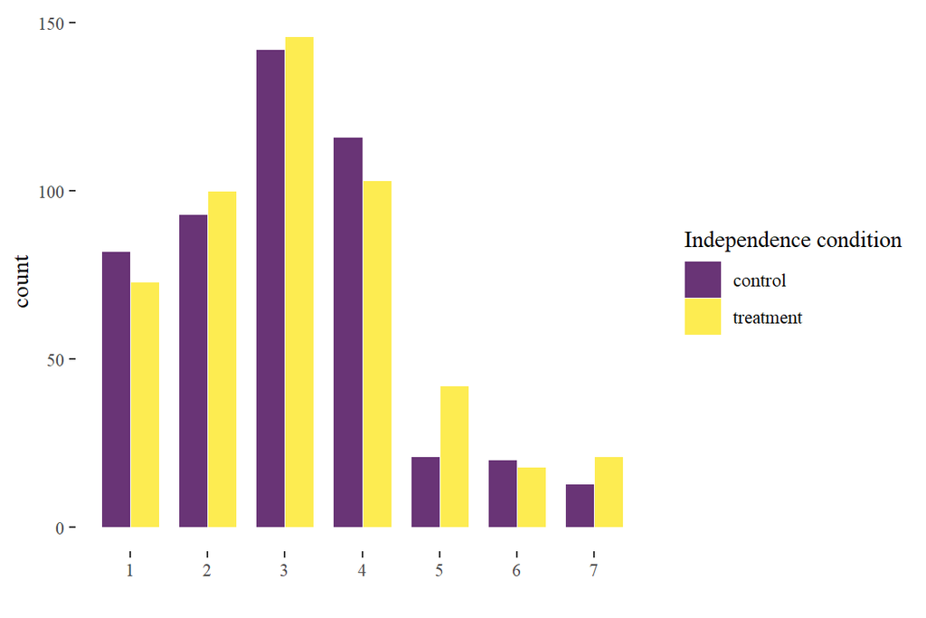

```r
df.def %>%
  ggplot(aes(x = perceived.independence.reversed, fill = experimental.group)) +
  geom_bar(width = 0.75,alpha = 0.8, position = position_dodge()) +
  scale_x_continuous(name="", breaks = 1:7) + scale_fill_manual(name = "Independence condition") +  scale_fill_viridis_d(name = "Independence condition") +
  theme_tufte()
```

## 2.4 T-test

### 2.4.1 With complete dataset

```r
tadaa_t.test(data = df.def, response = perceived.independence.reversed, group = experimental.group, print = "markdown")
```

Table 1: **Welch Two Sample t-test** with alternative hypothesis: $\mu_1 \neq \mu_2$

| Diff | $\mu_1$ treatment | $\mu_2$ control | t | SE | df | $CI_{95\%}$ | p | Cohen's d |
| --- | --- | --- | --- | --- | --- | --- | --- | --- |
| 0.13 | 3.16 | 3.03 | 1.39 | 0.09 | 987.73 | (-0.05 - 0.31) | .165 | 0.09 |

### 2.4.2 With those who failed the manipulation check filtered out

```r
tadaa_t.test(data = df.check, response = perceived.independence.reversed, group = experimental.group, print = "markdown")
```

Table 2: **Welch Two Sample t-test** with alternative hypothesis: $\mu_1 \neq \mu_2$

| Diff | $\mu_1$ treatment | $\mu_2$ control | t | SE | df | $CI_{95\%}$ | p | Cohen's d |
| --- | --- | --- | --- | --- | --- | --- | --- | --- |
| 0.3 | 3.27 | 2.97 | 2.35 | 0.13 | 519.45 | (0.05 - 0.55) | < .05 | 0.2 |

# 3 Time

## 3.1 Survey duration

### 3.1.1 Histogram

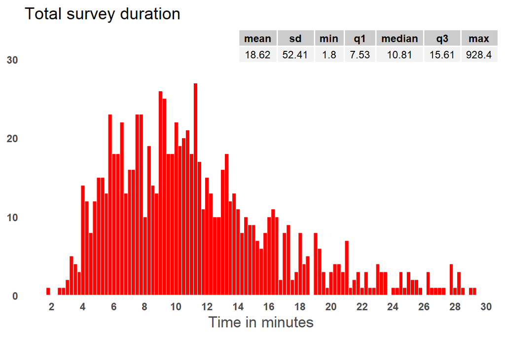

```r
df.def %>% filter(duration < 30) %>%
plot_frq((duration),
        geom.colors = alpha("red",0.8),
        type = "hist",
        geom.size = 0.25) +
  theme(axis.text = element_text(face = "bold",  size= 9)) + labs(title = "Total survey duration") +  scale_x_continuous(name="Time in minutes", breaks = seq(0,30, 2)) +  scale_y_continuous(expand = expansion(c(0, 0.25))) + annotate(geom = "table", x = Inf, y = Inf, label = list(table.duration))
```

### 3.1.2 Relationship between perceived independence and total survey duration

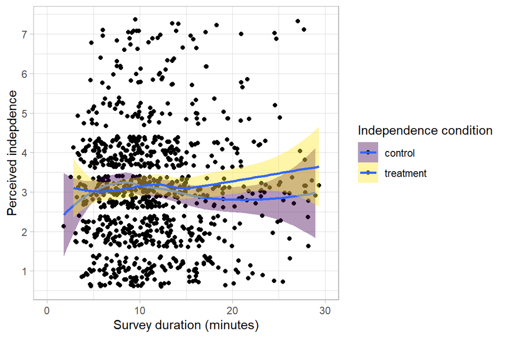

```r
df.def %>% filter(duration < 30) %>% ggplot(aes(duration, perceived.independence.reversed, fill = experimental.group)) + geom_jitter() + geom_smooth() + scale_x_continuous("Survey duration (minutes)", limits = c(0,30)) + scale_y_continuous("Perceived indepdence", breaks = 1:7) + scale_fill_viridis_d(name = "Independence condition") + theme_light()
```

## 3.2 Do participants read the information about the case?

### 3.2.1 Page submission - introduction of case

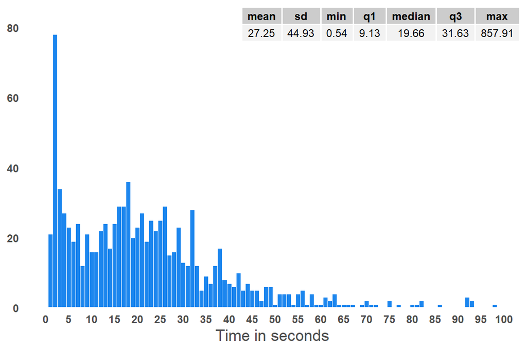

```r
df.def %>% filter(intro.submit < 100) %>%
plot_frq((intro.submit),
        geom.colors = alpha("dodgerblue2",0.8),
        type = "hist",
        geom.size = 1) +
  theme(axis.text = element_text(face = "bold",  size= 9)) +
  scale_x_continuous(name="Time in seconds",breaks = seq(0,100,5)) +   scale_y_continuous(expand = expansion(c(0, 0.1))) + annotate(geom = "table", x = Inf, y = Inf, label = list(table.intro.submit))
```

### 3.2.2 Page submission - manipulation

*Histogram*

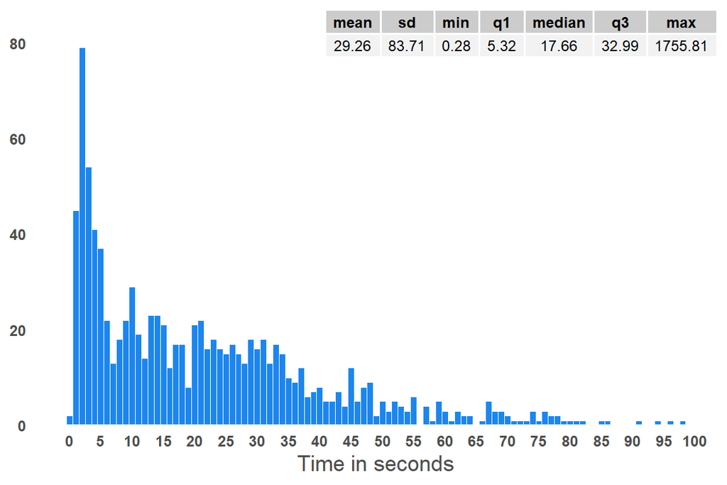

```r
df.def %>% filter(manipulation.submit < 100) %>%
plot_frq((manipulation.submit),
        geom.colors = alpha("dodgerblue2",0.8),
        type = "hist",
        geom.size = 1) +
  theme(axis.text = element_text(face = "bold",  size= 9)) +
  scale_x_continuous(name="Time in seconds",breaks = seq(0,100,5)) +   scale_y_continuous(expand = expansion(c(0, 0.1))) + annotate(geom = "table", x = Inf, y = Inf, label = list(table.manipulation.submit))
```

*Relationship between perceived independence and time spent on the page with the manipulation*

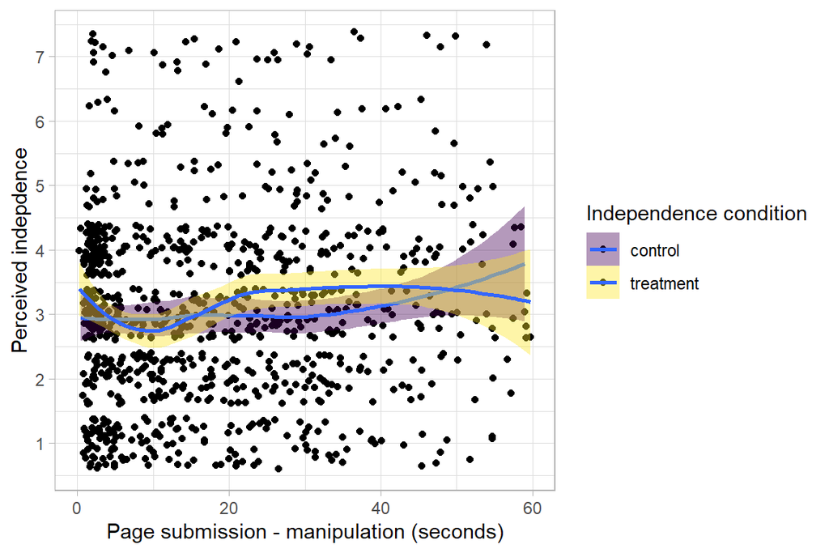

```r
df.def %>% filter(manipulation.submit < 60) %>% ggplot(aes(manipulation.submit, perceived.independence.reversed, fill = experimental.group)) + geom_jitter() + geom_smooth() + scale_x_continuous("Page submission - manipulation (seconds)", limits = c(0,60)) + scale_y_continuous("Perceived indepdence", breaks = 1:7) + scale_fill_viridis_d(name = "Independence condition") + theme_light()
```

*Broken down in quartiles (+ group size and CI)*

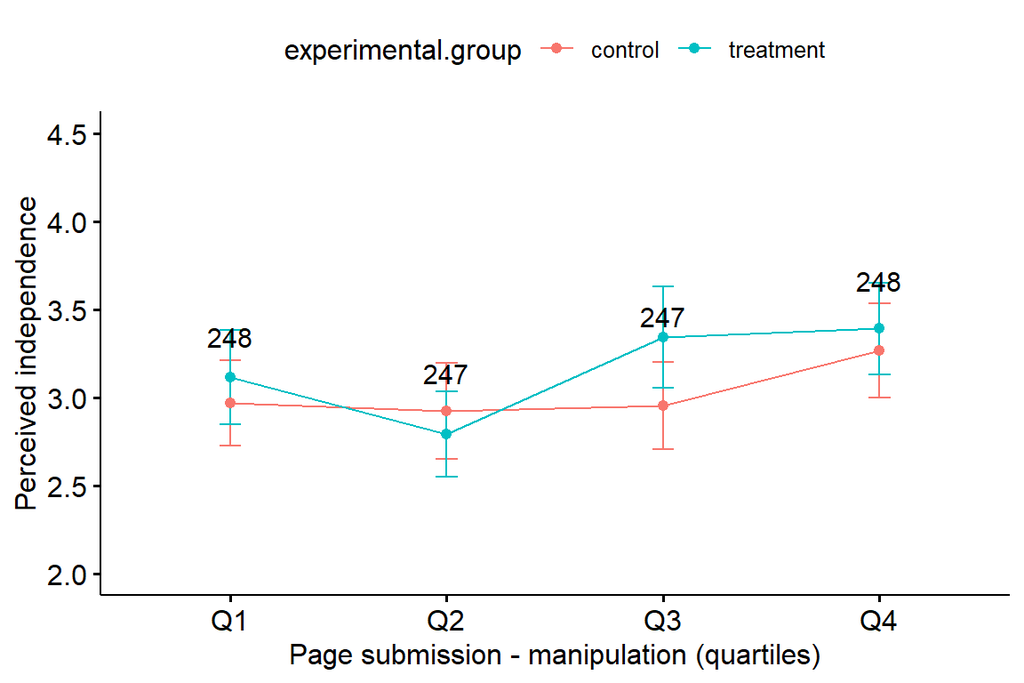

```r
give.n <- function(x){
  return(c(y = mean(x)*1.1, label = length(x)))
}

ggline(df.def, x = "manipulation.submit.quartile", y = "perceived.independence.reversed", color = "experimental.group", ylab = "Perceived independence", xlab = "Page submission - manipulation (quartiles)",  add = "mean_ci", ylim = c(2, 4.5), yticks.by = 0.5) +
  stat_summary(fun.data = give.n, geom = "text", fun = median, size = 4, col = "black")
```

*Split dataset with 30 seconds as cut-off point (+ group size and CI)*

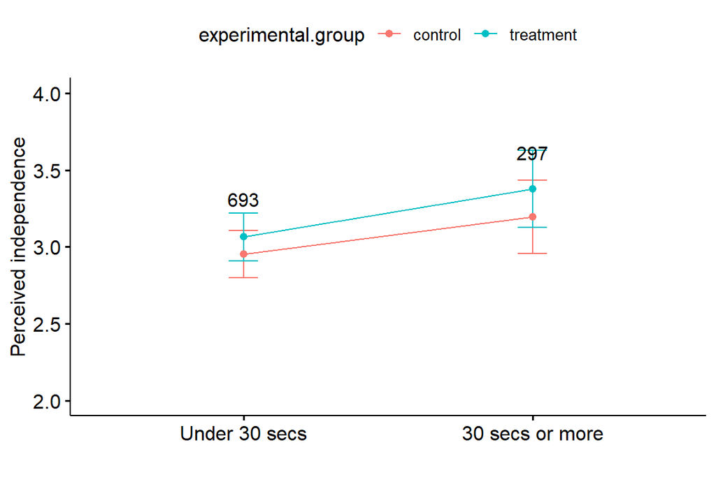

```r
ggline(df.def, x = "manipulation.submit.30", y = "perceived.independence.reversed", color = "experimental.group", ylab = "Perceived independence", xlab = "",  add = "mean_ci", ylim = c(2, 4), yticks.by = 0.5) +
  stat_summary(fun.data = give.n, geom = "text", fun = median, size = 4, col = "black")
```

### 3.2.3 Page submission - EMA’s decision

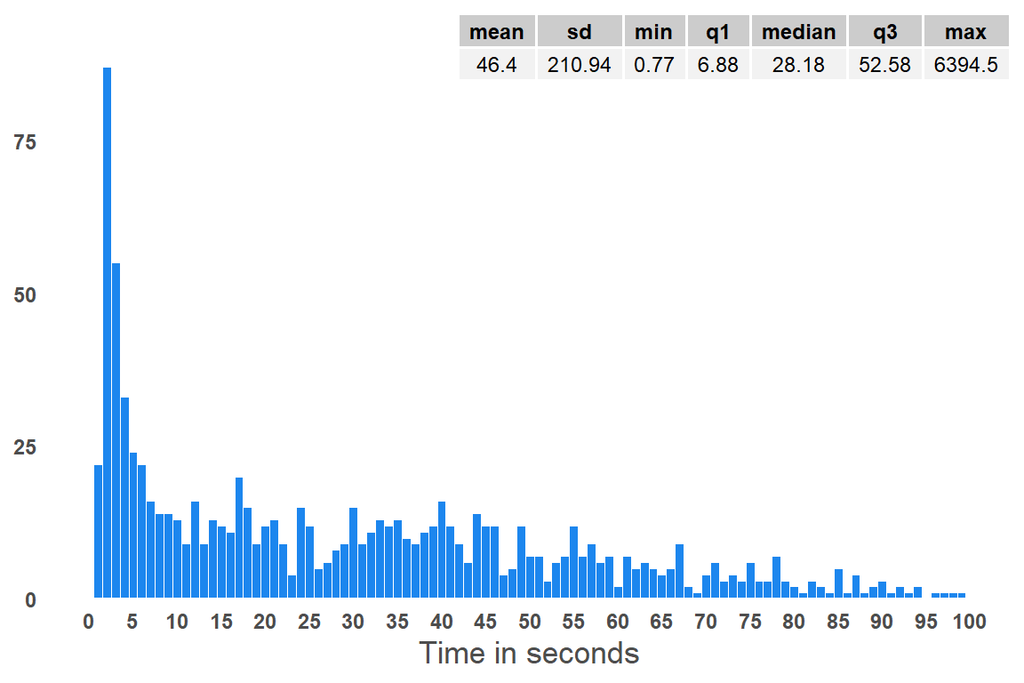

```r
df.def %>% filter(decision.submit < 100) %>%
plot_frq((decision.submit),
        geom.colors = alpha("dodgerblue2",0.8),
        type = "hist",
        geom.size = 1) +
  theme(axis.text = element_text(face = "bold",  size= 9)) +
  scale_x_continuous(name= "Time in seconds", breaks = seq(0,100,5)) +   scale_y_continuous(expand = expansion(c(0, 0.1))) + annotate(geom = "table", x = Inf, y = Inf, label = list(table.decision.submit))
```

### 3.2.4 Time and …

*…Failing the manipulation check*

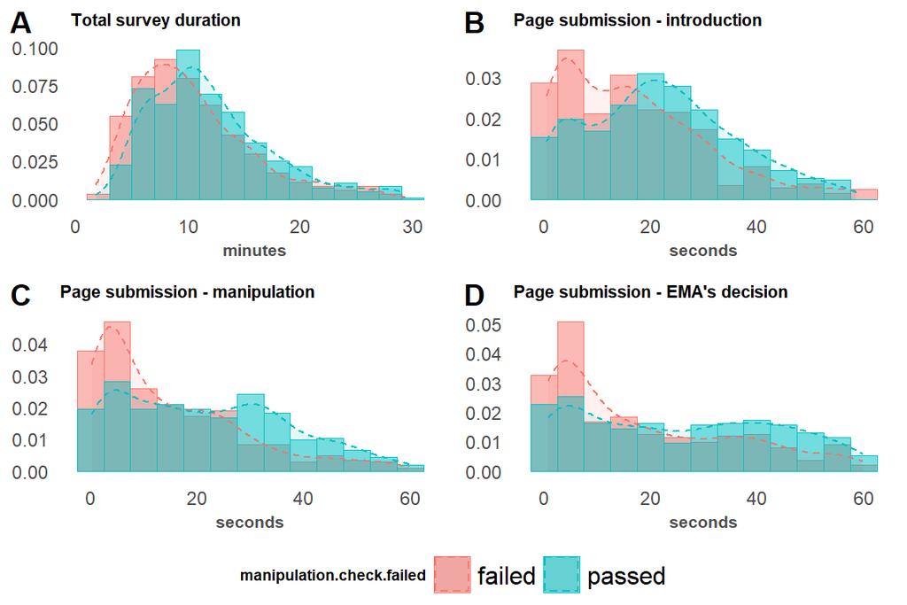

```r
p1 <- df.def %>% filter(duration < 30) %>% ggplot(aes(x= duration, color = manipulation.check.failed, fill = manipulation.check.failed)) + geom_histogram(aes(y=..density..), alpha=0.5, position="identity", binwidth = 2) +
 geom_density(alpha= .1, linetype= "dashed") + labs(title = "Total survey duration", x = "minutes") + theme(axis.title.y = element_blank(), title = element_text(size = 7, face = "bold"),  axis.text = element_text(size = 9))

p2  <- df.def %>% filter(intro.submit < 60) %>% ggplot(aes(x= intro.submit, color = manipulation.check.failed, fill = manipulation.check.failed)) + geom_histogram(aes(y=..density..), alpha=0.5, position="identity", binwidth = 5) +
 geom_density(alpha= .1, linetype= "dashed") + labs(title = "Page submission - introduction", x = "seconds") + theme(axis.title.y = element_blank(), title = element_text(size = 7, face = "bold"),  axis.text = element_text(size = 9))

p3 <- df.def %>% filter(manipulation.submit < 60) %>% ggplot(aes(x=manipulation.submit, color = manipulation.check.failed, fill = manipulation.check.failed)) + geom_histogram(aes(y=..density..), alpha=0.5, position="identity", binwidth = 5) + geom_density(alpha= .1, linetype= "dashed") + labs(title = "Page submission - manipulation", x = "seconds") + theme(axis.title.y = element_blank(), title = element_text(size = 7, face = "bold"),  axis.text = element_text(size = 9))

p4 <- df.def %>% filter(decision.submit < 60) %>% ggplot(aes(x=decision.submit, color =manipulation.check.failed, fill = manipulation.check.failed)) +
 geom_histogram(aes(y=..density..), alpha=0.5, position="identity", binwidth = 5) +
 geom_density(alpha= .1, linetype= "dashed") + labs(title = "Page submission - EMA's decision", x = "seconds", color = "Manipulation Check") + theme(axis.title.y = element_blank(), title = element_text(size = 7, face = "bold"),  axis.text = element_text(size = 9))

ggarrange(p1, p2, p3, p4, nrow = 2, ncol = 2, labels="AUTO", legend = "bottom", common.legend = TRUE)
```

*…experimental groups*

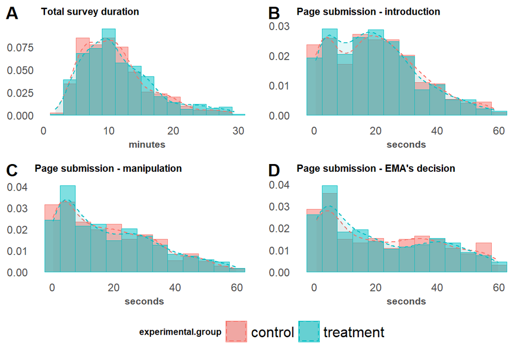

```r
p5 <- df.def %>% filter(duration < 30) %>% ggplot(aes(x= duration, color = experimental.group, fill = experimental.group)) + geom_histogram(aes(y=..density..), alpha=0.5, position="identity", binwidth = 2) +
 geom_density(alpha= .1, linetype= "dashed") + labs(title = "Total survey duration", x = "minutes") + theme(axis.title.y = element_blank(), title = element_text(size = 7, face = "bold"),  axis.text = element_text(size = 9))

p6  <- df.def %>% filter(intro.submit < 60) %>% ggplot(aes(x= intro.submit, color = experimental.group, fill = experimental.group)) + geom_histogram(aes(y=..density..), alpha=0.5, position="identity", binwidth = 5) +
 geom_density(alpha= .1, linetype= "dashed") + labs(title = "Page submission - introduction", x = "seconds") + theme(axis.title.y = element_blank(), title = element_text(size = 7, face = "bold"),  axis.text = element_text(size = 9))

p7 <- df.def %>% filter(manipulation.submit < 60) %>% ggplot(aes(x=manipulation.submit, color = experimental.group, fill = experimental.group)) + geom_histogram(aes(y=..density..), alpha=0.5, position="identity", binwidth = 5) + geom_density(alpha= .1, linetype= "dashed") + labs(title = "Page submission - manipulation", x = "seconds") + theme(axis.title.y = element_blank(), title = element_text(size = 7, face = "bold"),  axis.text = element_text(size = 9))

p8 <- df.def %>% filter(decision.submit < 60) %>% ggplot(aes(x=decision.submit, color = experimental.group, fill = experimental.group)) +
 geom_histogram(aes(y=..density..), alpha=0.5, position="identity", binwidth = 5) +
 geom_density(alpha= .1, linetype= "dashed") + labs(title = "Page submission - EMA's decision", x = "seconds", color = "Manipulation Check") + theme(axis.title.y = element_blank(), title = element_text(size = 7, face = "bold"),  axis.text = element_text(size = 9))

ggarrange(p5, p6, p7, p8, nrow = 2, ncol = 2, labels="AUTO", legend = "bottom", common.legend = TRUE)
```

T-tests (outliers removed - i.e., cases outside 1.5 times the interquartile range):

*Survey duration*

```r
tadaa_t.test(data = out.duration, response = duration, group = experimental.group, print = "markdown")
```

Table 3: **Welch Two Sample t-test** with alternative hypothesis: $\mu_1 \neq \mu_2$

| Diff | $\mu_1$ treatment | $\mu_2$ control | t | SE | df | $CI_{95\%}$ | p | Cohen's d |
| --- | --- | --- | --- | --- | --- | --- | --- | --- |
| 0.33 | 11.26 | 10.92 | 0.99 | 0.34 | 903.77 | (-0.33 - 0.99) | .322 | 0.07 |

*Page submission - Introduction*

```r
tadaa_t.test(data = out.intro.submit, response = intro.submit, group = experimental.group, print = "markdown")
```

Table 4: **Welch Two Sample t-test** with alternative hypothesis: $\mu_1 \neq \mu_2$

| Diff | $\mu_1$ treatment | $\mu_2$ control | t | SE | df | $CI_{95\%}$ | p | Cohen's d |
| --- | --- | --- | --- | --- | --- | --- | --- | --- |
| -0.23 | 20.22 | 20.45 | -0.24 | 0.94 | 934.45 | (-2.07 - 1.62) | .809 | -0.02 |

*Page submission - manipulation*

```r
tadaa_t.test(data = out.manipulation.submit, response = manipulation.submit, group = experimental.group, print = "markdown")
```

Table 5: **Welch Two Sample t-test** with alternative hypothesis: $\mu_1 \neq \mu_2$

| Diff | $\mu_1$ treatment | $\mu_2$ control | t | SE | df | $CI_{95\%}$ | p | Cohen's d |
| --- | --- | --- | --- | --- | --- | --- | --- | --- |
| 0.2 | 20.29 | 20.09 | 0.18 | 1.12 | 939.47 | (-1.99 - 2.39) | .859 | 0.01 |

*Page submission - decision*

```r
tadaa_t.test(data = out.decision.submit, response = decision.submit, group = experimental.group, print = "markdown")
```

Table 6: **Welch Two Sample t-test** with alternative hypothesis: $\mu_1 \neq \mu_2$

| Diff | $\mu_1$ treatment | $\mu_2$ control | t | SE | df | $CI_{95\%}$ | p | Cohen's d |
| --- | --- | --- | --- | --- | --- | --- | --- | --- |
| -1.84 | 30.59 | 32.42 | -1.01 | 1.81 | 939.92 | (-5.39 - 1.72) | .311 | -0.07 |

*…interface (pc/mobile)*

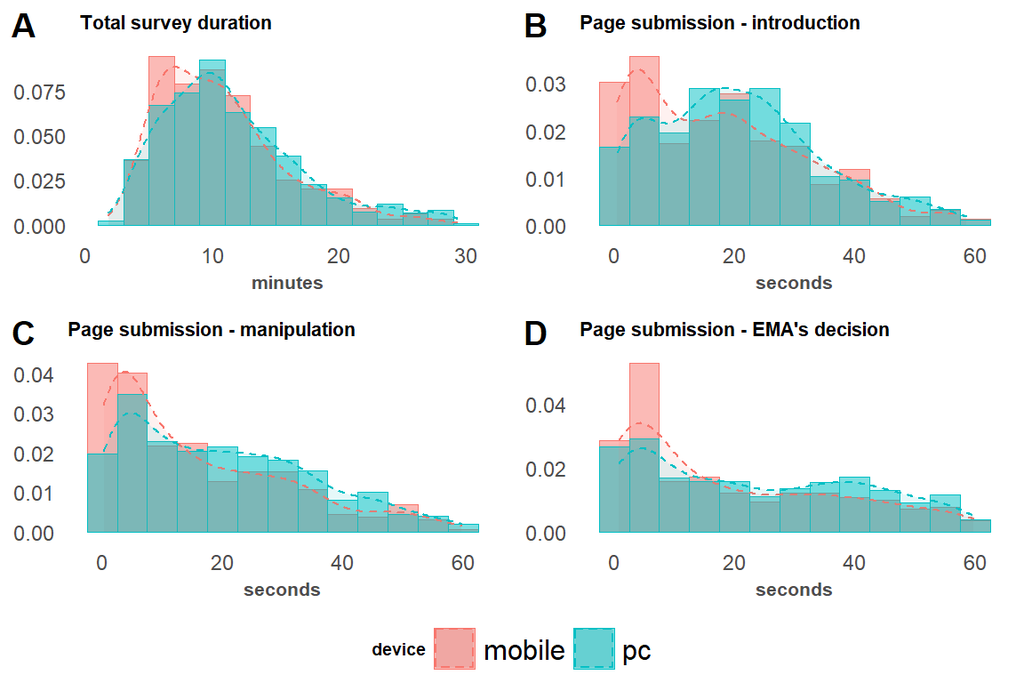

```r
p9 <- df.def %>% filter(duration < 30) %>% ggplot(aes(x= duration, color = device, fill = device)) + geom_histogram(aes(y=..density..), alpha=0.5, position="identity", binwidth = 2) +
 geom_density(alpha= .1, linetype= "dashed") + labs(title = "Total survey duration", x = "minutes") + theme(axis.title.y = element_blank(), title = element_text(size = 7, face = "bold"),  axis.text = element_text(size = 9))

p10 <- df.def %>% filter(intro.submit < 60) %>% ggplot(aes(x= intro.submit, color = device, fill = device)) + geom_histogram(aes(y=..density..), alpha=0.5, position="identity", binwidth = 5) +
 geom_density(alpha= .1, linetype= "dashed") + labs(title = "Page submission - introduction", x = "seconds") + theme(axis.title.y = element_blank(), title = element_text(size = 7, face = "bold"),  axis.text = element_text(size = 9))

p11 <- df.def %>% filter(manipulation.submit < 60) %>% ggplot(aes(x=manipulation.submit, color = device, fill = device)) + geom_histogram(aes(y=..density..), alpha=0.5, position="identity", binwidth = 5) + geom_density(alpha= .1, linetype= "dashed") + labs(title = "Page submission - manipulation", x = "seconds") + theme(axis.title.y = element_blank(), title = element_text(size = 7, face = "bold"),  axis.text = element_text(size = 9))

p12 <- df.def %>% filter(decision.submit < 60) %>% ggplot(aes(x=decision.submit, color = device, fill = device)) +
 geom_histogram(aes(y=..density..), alpha=0.5, position="identity", binwidth = 5) +
 geom_density(alpha= .1, linetype= "dashed") + labs(title = "Page submission - EMA's decision", x = "seconds", color = "Manipulation Check") + theme(axis.title.y = element_blank(), title = element_text(size = 7, face = "bold"),  axis.text = element_text(size = 9))

ggarrange(p9, p10, p11, p12, nrow = 2, ncol = 2, labels="AUTO", legend = "bottom", common.legend = TRUE)
```

# 4 Vaccination intention

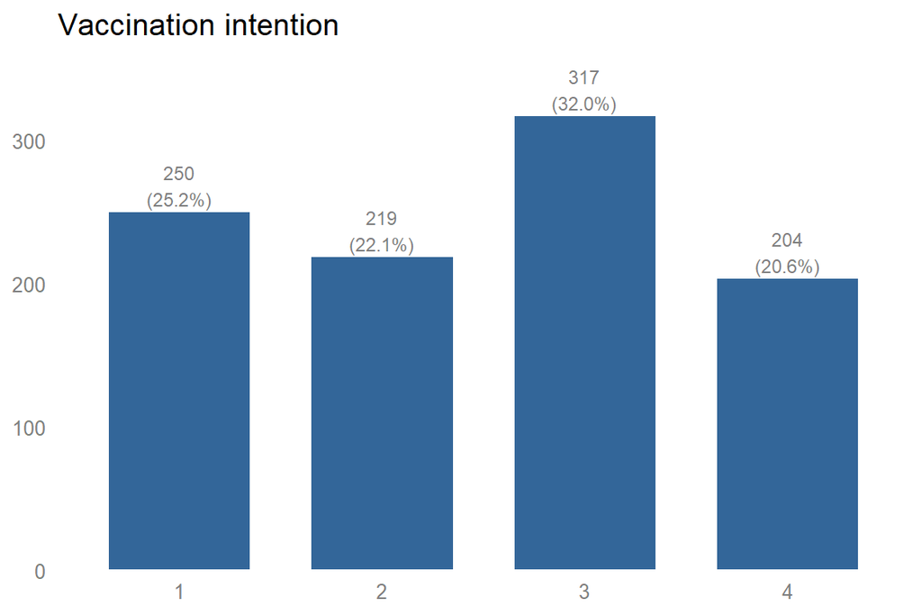

```r
df.def %>%
plot_frq(intent.vaccine,
        title = "Vaccination intention") +
  theme_blank() +
  theme(axis.title  = element_blank())
```

## 4.1 Open question

```r
df.def %>%
  filter(nchar(Q16.3)>1) %>%
  select(Q16.3) %>%
  kable() %>%
  kable_styling(bootstrap_options = "striped", full_width = F) %>%    scroll_box(height = "400px")
```

[output not shown]

# 5 Interface (mobile/pc)

## 5.1 Distribution

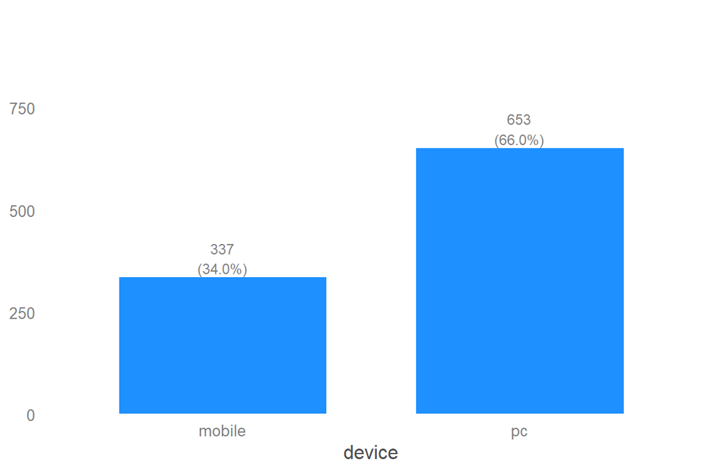

```r
df.def %>%
  plot_frq(device,
        ylim = c(0,nrow(df.def)),
        geom.colors = alpha("dodgerblue1",0.8))+
  theme_blank()
```

## 5.2 Distribution of perceived independence for mobile/pc

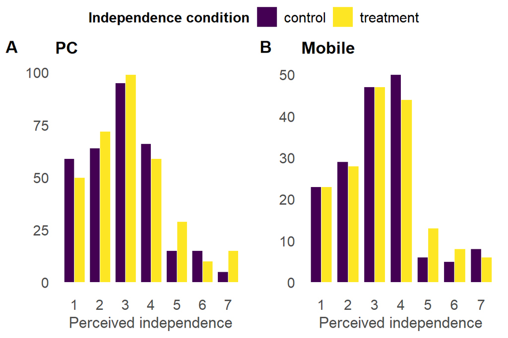

```r
p13 <- df.def %>%
  drop_na(perceived.independence.reversed) %>% filter(device == "pc") %>%
  ggplot(aes(x = perceived.independence.reversed, fill = experimental.group)) + labs(title = "PC") +
  geom_bar(width = 0.8, alpha = 1, position = position_dodge()) +
  scale_x_continuous(name="Perceived independence", breaks = 1:7) + scale_y_continuous(name="") + scale_fill_manual(name = "Independence condition", values = c("dodgerblue2","dodgerblue4")) +
theme(plot.title = element_text(face = "bold")) +  scale_fill_viridis_d(name = "Independence condition")

p14 <- df.def %>% filter(device == "mobile") %>%
  ggplot(aes(x = perceived.independence.reversed, fill = experimental.group)) + labs(title = "Mobile") +
  geom_bar(width = 0.8, alpha = 1, position = position_dodge())+
  scale_x_continuous(name="Perceived independence", breaks = 1:7) + scale_y_continuous(name="") + scale_fill_manual(name = "Independence condition", values = c("dodgerblue2","dodgerblue4")) +
theme(plot.title = element_text(face = "bold")) +  scale_fill_viridis_d(name = "Independence condition")

ggarrange(p13, p14,
          ncol = 2,nrow = 1, common.legend = TRUE, labels = "AUTO")
```

### 5.2.1 T-test

```r
tadaa_t.test(data = df.def, response = perceived.independence.reversed, group = device, print = "markdown")
```

Table 7: **Welch Two Sample t-test** with alternative hypothesis: $\mu_1 \neq \mu_2$

| Diff | $\mu_1$ mobile | $\mu_2$ pc | t | SE | df | $CI_{95\%}$ | p | Cohen's d |
| --- | --- | --- | --- | --- | --- | --- | --- | --- |
| 0.21 | 3.23 | 3.02 | 2.12 | 0.1 | 677.72 | (0.02 - 0.4) | < .05 | 0.14 |

# 6 Descriptive statistics

## 6.1 Demography

**Age**

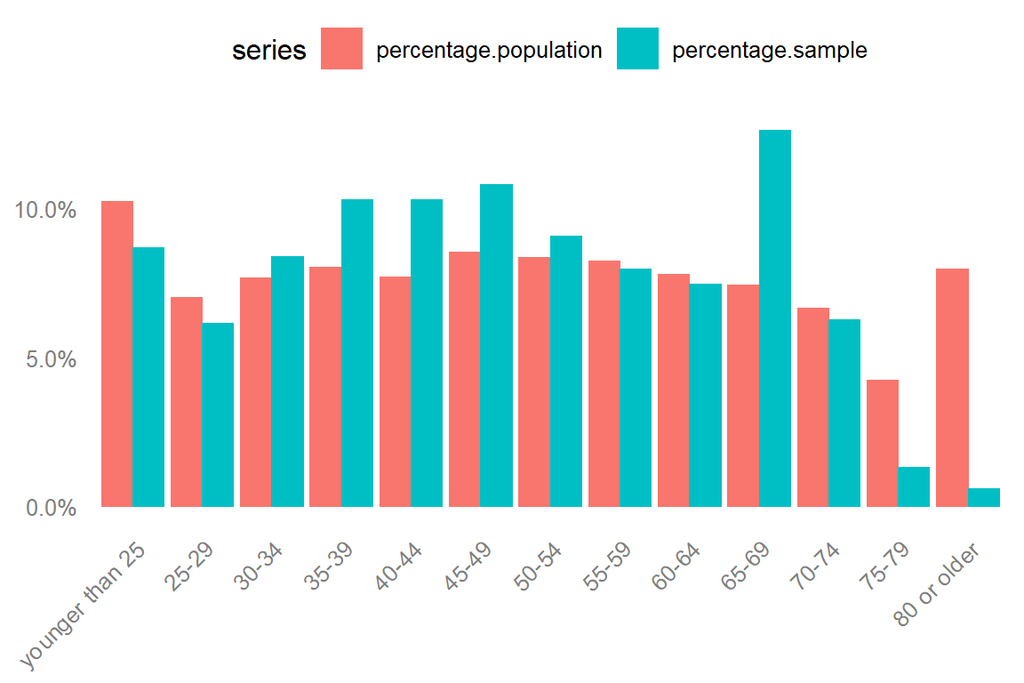

```r
age.population <- read.csv("AGE_FR-08022021.csv")
agecut.5 <- c(-Inf, 25, 30, 35, 40, 45, 50, 55, 60, 65, 70, 75, 80, Inf)


age.population <- age.population %>% mutate(agecat = case_when(age < 25 ~ "younger than 25",
          age >= 25 & age < 30 ~ "25-29",
          age >= 30 & age < 35 ~ "30-34",
          age >= 35 & age < 40 ~ "35-39",
          age >= 40 & age < 45 ~ "40-44",
          age >= 45 & age < 50 ~ "45-49",
          age >= 50 & age < 55 ~ "50-54",
          age >= 55 & age < 60 ~ "55-59",
          age >= 60 & age < 65 ~ "60-64",
          age >= 65 & age < 70 ~ "65-69",
          age >= 70 & age < 75 ~ "70-74",
          age >= 75 & age < 80 ~ "75-79",
          age >= 80 ~ "80 or older"))

age.population.5 <- age.population %>% group_by(agecat) %>% tally(count) %>% mutate(percentage = n / sum(n))

age.total <- merge(age.population.5, age.sample, by.x = "agecat", by.y = ".")

age.total <- age.total %>%
  rename(age.category = agecat,
  count.population = n.x,
  count.sample = n.y,
  percentage.population = percentage.x,
  percentage.sample = percentage.y)

age.total$age.category <- factor(age.total$age.category, levels = c(
"younger than 25",
"25-29",           "30-34",           "35-39",
"40-44",           "45-49",           "50-54",
"55-59",           "60-64",           "65-69",
"70-74",           "75-79",           "80 or older"))

age.total %>% select(age.category, percentage.population, percentage.sample) %>% reshape2::melt(id.vars = 'age.category', variable.name = 'series')  %>% ggplot(aes(age.category, value, colour = series, fill = series)) + geom_bar (stat="identity", width=0.9, position = position_dodge(width=0.9)) +
  theme_blank() + theme(legend.position="top", axis.text.x = element_text(angle = 45, hjust = 1), axis.title  = element_blank()) + scale_y_continuous(labels=scales::percent)
```

**Gender**

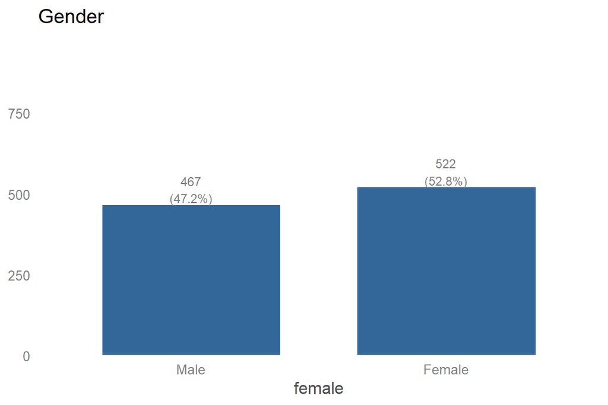

```r
df.def %>%
plot_frq(female,
                ylim = c(0,nrow(df.def)),
        axis.labels = c("Male","Female"),
        title = "Gender")+
  theme_blank()
```

**Education**

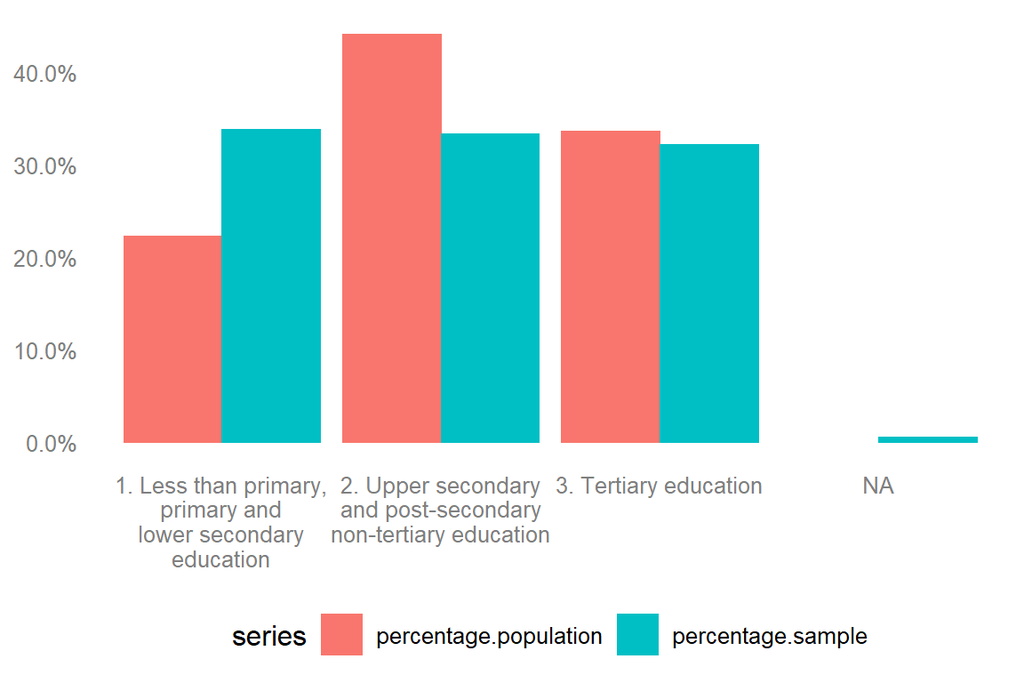

```r
education.population <- read.csv("EDUCATION_FR-08022021.csv")

education.sample.eurostat <-  df.def %>% drop_na(education.recoded)  %>% filter(age <75)  %>%  count(education.recoded) %>%
  mutate(percentage = n / sum(n))

education.total.eurostat <- merge(education.population, education.sample.eurostat, by.x = "ï..education", by.y = "education.recoded", all = TRUE)

education.total.eurostat <- education.total.eurostat %>%
  rename(education.category = ï..education,
  count.population = count,
  count.sample = n,
  percentage.population = percentage.x,
  percentage.sample = percentage.y)

my.labels.eurostat <- c('1. Less than primary,\nprimary and\nlower secondary\neducation',
               '2. Upper secondary\nand post-secondary\nnon-tertiary education',
         '3. Tertiary education')

education.total.eurostat %>% select(education.category, percentage.population, percentage.sample) %>% reshape2::melt(id.vars = 'education.category', variable.name = 'series')  %>% ggplot(aes(education.category, value, colour = series, fill = series)) + geom_bar (stat="identity", width=0.9, position = position_dodge(width=0.9)) +
  theme_blank() + theme(legend.position="bottom", axis.title  = element_blank()) + scale_y_continuous(labels=scales::percent) + scale_x_discrete(labels= my.labels.eurostat)
```

**Income**

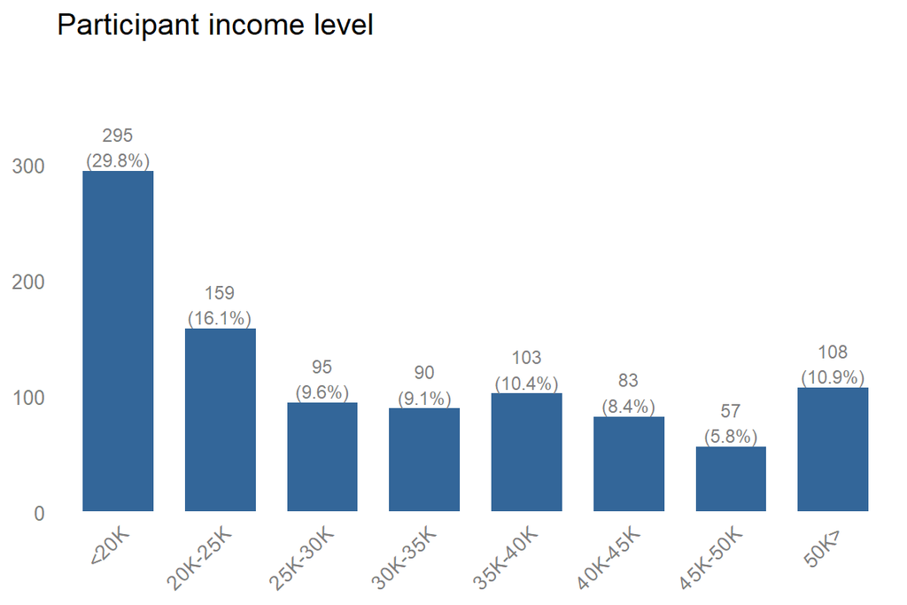

```r
df.def %>%
  filter(income!=0) %>%
  plot_frq(income,
        ylim = c(0,nrow(df.def)/2.5),
        title = "Participant income level") +
  theme_blank() + theme(axis.text.x = element_text(angle = 45, hjust = 1), axis.title  = element_blank())
```

**Province**

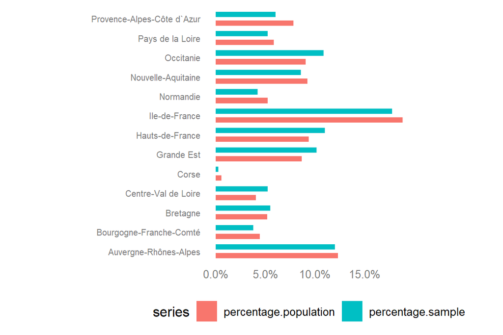

**Works in healthcare sector**

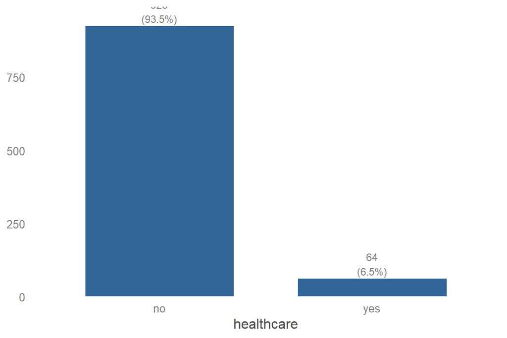

```r
df.def %>%
  plot_frq(healthcare,
        ylim = c(0,nrow(df.def)),
        title = "") +
  theme_blank()
```

# 7 Pre-post

## 7.1 Correlation matrix

```r
df.def %>%
  select(credibility.EMA,
         credibility.post,
         credibility.expert,
         credibility.noninterference,
         credibility.stability,
         credibility.index,
         perceived.independence.reversed,
         intent.vaccine,
         ) %>%
  tab_corr(triangle="lower",
           remove.spaces=T,
           p.numeric = T,
           fade.ns = T,
           digits = 2,
           na.deletion="pairwise",
           title = "Correlation matrix")
```

Correlation matrix

|  | credibility.EMA | credibility.post | credibility.expert | credibility.noninterference | credibility.stability | credibility.index | perceived.independence.reversed | intent.vaccine |
| --- | --- | --- | --- | --- | --- | --- | --- | --- |
| credibility.EMA |  |  |  |  |  |  |  |  |
| credibility.post | 0.62 (<.001) |  |  |  |  |  |  |  |
| credibility.expert | 0.55 (<.001) | 0.77 (<.001) |  |  |  |  |  |  |
| credibility.noninterference | 0.45 (<.001) | 0.60 (<.001) | 0.60 (<.001) |  |  |  |  |  |
| credibility.stability | 0.23 (<.001) | 0.35 (<.001) | 0.43 (<.001) | 0.18 (<.001) |  |  |  |  |
| credibility.index | 0.55 (<.001) | 0.76 (<.001) | 0.86 (<.001) | 0.89 (<.001) | 0.49 (<.001) |  |  |  |
| perceived.independence.reversed | 0.05 (.12) | 0.05 (.13) | 0.02 (.55) | 0.33 (<.001) | -0.13 (<.001) | 0.18 (<.001) |  |  |
| intent.vaccine | 0.38 (<.001) | 0.50 (<.001) | 0.53 (<.001) | 0.45 (<.001) | 0.24 (<.001) | 0.54 (<.001) | 0.04 (.21) |  |
| Computed correlation used pearson-method with pairwise-deletion. |  |  |  |  |  |  |  |  |

## 7.2 Plots

### 7.2.1 Total

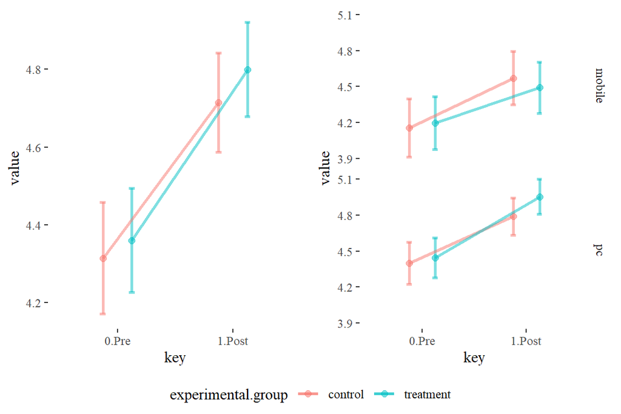

```r
table.prepost <- df.def  %>%
  select(experimental.group,
         credibility.EMA,
         credibility.post,
         device) %>%
  gather("key","value",-experimental.group, -device) %>%
  mutate(key = recode(key,"'credibility.EMA'='0.Pre';'credibility.post'='1.Post'"))

ggarrange(table.prepost %>% ggplot(aes(x=key,y=value,color=experimental.group))+
      stat_summary(fun.data = mean_cl_normal, geom = "errorbar", alpha=0.5,width=0.1,size=1,position=position_dodge(0.5)) +
  stat_summary(fun = mean, geom = "point", alpha=0.5,size=2,position=position_dodge(0.5))+
  stat_summary(fun = mean, geom = "line", alpha=0.5,size=1,position=position_dodge(0.5), aes(group = experimental.group)) +
  theme_tufte(),

  table.prepost %>% ggplot( aes(x=key,y=value,color=experimental.group))+
      stat_summary(fun.data = mean_cl_normal, geom = "errorbar", alpha=0.5,width=0.1,size=1,position=position_dodge(0.5)) +
  stat_summary(fun = mean, geom = "point", alpha=0.5,size=2,position=position_dodge(0.5))+
  stat_summary(fun = mean, geom = "line", alpha=0.5,size=1,position=position_dodge(0.5), aes(group = experimental.group)) + facet_grid(vars(device)) +
  theme_tufte(), common.legend = TRUE, legend   = "bottom", ncol = 2)
```

This code returns a warning. However, the resulting dataframe does not have NAs:

```r
colSums(is.na(table.prepost))
```

```
## experimental.group             device                key              value
##                  0                  0                  0                  0
```

## 7.3 Regression

```r
t1 <- df.def %>% mutate(id = row_number()) %>%
  select(experimental.group,
         id,
         credibility.EMA,
         credibility.post) %>%
  drop_na() %>%
  gather("key","value",-experimental.group,-id) %>%
  mutate(post = key %>% Recode("'credibility.EMA'= 0;'credibility.post'=1"),
         EMA.credibility = value)


tmod1 <- lmer(EMA.credibility ~ post + (1|id),
                       data = t1)

tmod2 <- tmod1 %>% update(.~.+experimental.group)


tmod3 <- tmod2 %>% update(.~. + post*experimental.group)

tab_model(tmod2,tmod3,
          show.ci = F,
          show.se = T,
          collapse.se = T,
          emph.p = F)
```

|  | EMA credibility |  | EMA credibility |  |
| --- | --- | --- | --- | --- |
| Predictors | Estimates | p | Estimates | p |
| (Intercept) | 4.30 (0.06) | <0.001 | 4.31 (0.07) | <0.001 |
| post | 0.42 (0.04) | <0.001 | 0.40 (0.06) | <0.001 |
| experimental.group [treatment] | 0.07 (0.09) | 0.445 | 0.05 (0.09) | 0.630 |
| post * experimental.group [treatment] |  |  | 0.04 (0.08) | 0.639 |
| Random Effects |  |  |  |  |
| σ<sup>2</sup> | 0.85 |  | 0.85 |  |
| τ<sub>00</sub> | 1.37 <sub>id</sub> |  | 1.37 <sub>id</sub> |  |
| ICC | 0.62 |  | 0.62 |  |
| N | 990 <sub>id</sub> |  | 990 <sub>id</sub> |  |
| Observations | 1980 |  | 1980 |  |
| Marginal R<sup>2</sup> / Conditional R<sup>2</sup> | 0.020 / 0.624 |  | 0.020 / 0.624 |  |

## 7.4 Distribution of credibility EMA (**pre**)

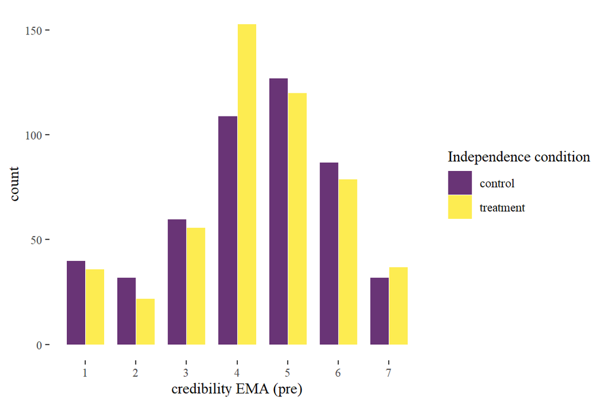

```r
df.def %>%
  ggplot(aes(x = credibility.EMA, fill = experimental.group)) +
  geom_bar(width = 0.75,alpha = 0.8, position = position_dodge()) +
  scale_x_continuous(name="credibility EMA (pre)", breaks = 1:7) + scale_fill_manual(name = "Independence condition") +  scale_fill_viridis_d(name = "Independence condition") +
  theme_tufte()
```

## 7.5 Distribution of credibility EMA (**post**)

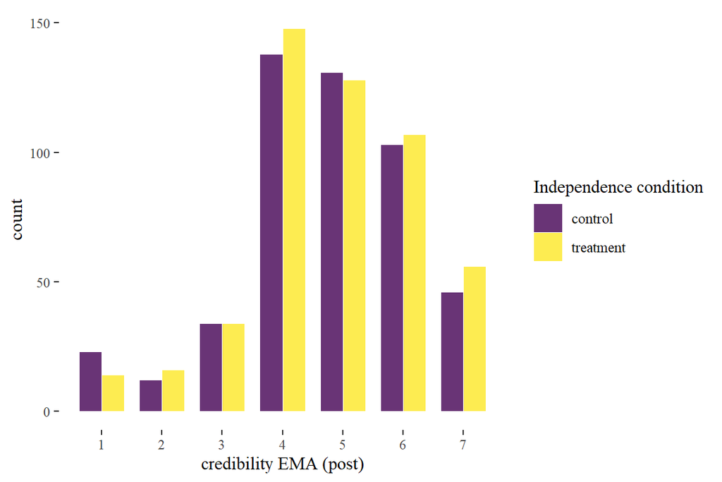

```r
df.def %>%
  ggplot(aes(x = credibility.post, fill = experimental.group)) +
  geom_bar(width = 0.75,alpha = 0.8, position = position_dodge()) +
  scale_x_continuous(name="credibility EMA (post)", breaks = 1:7) + scale_fill_manual(name = "Independence condition") +  scale_fill_viridis_d(name = "Independence condition") +
  theme_tufte()
```

# 8 Key variables

## 8.1 Statistics

```r
df.def %>% select(benefits.vaccines, intent.vaccine:importance.NRA, knowledge) %>%
sjmisc::descr(show = c("n", "NA.prc", "mean", "sd", "md", "iqr", "trimmed", "range", "skew")) %>%
  kbl(digits= 2) %>%
 kable_paper()
```

|  | var | n | NA.prc | mean | sd | md | trimmed | range | iqr | skew |
| --- | --- | --- | --- | --- | --- | --- | --- | --- | --- | --- |
| 1 | benefits.vaccines | 990 | 0.0 | 4.89 | 1.64 | 5.00 | 5.05 | 6 (1-7) | 2.00 | -0.61 |
| 24 | intent.vaccine | 990 | 0.0 | 2.48 | 1.08 | 3.00 | 2.47 | 3 (1-4) | 2.00 | -0.06 |
| 25 | intent.vaccine.recoded | 990 | 0.0 | 0.53 | 0.50 | 1.00 | 0.53 | 1 (0-1) | 1.00 | -0.11 |
| 9 | credibility.item1 | 990 | 0.0 | 4.74 | 1.51 | 5.00 | 4.84 | 6 (1-7) | 2.00 | -0.56 |
| 10 | credibility.item2.reversed | 990 | 0.0 | 3.58 | 1.64 | 4.00 | 3.53 | 6 (1-7) | 2.00 | 0.23 |
| 11 | credibility.item3.reversed | 990 | 0.0 | 3.55 | 1.65 | 4.00 | 3.49 | 6 (1-7) | 2.00 | 0.25 |
| 12 | credibility.item4 | 990 | 0.0 | 4.97 | 1.43 | 5.00 | 5.07 | 6 (1-7) | 2.00 | -0.64 |
| 13 | credibility.item5 | 990 | 0.0 | 4.88 | 1.43 | 5.00 | 4.96 | 6 (1-7) | 2.00 | -0.52 |
| 14 | credibility.item6 | 990 | 0.0 | 5.11 | 1.33 | 5.00 | 5.16 | 6 (1-7) | 2.00 | -0.39 |
| 17 | credibility.stability | 990 | 0.0 | 5.11 | 1.33 | 5.00 | 5.16 | 6 (1-7) | 2.00 | -0.39 |
| 8 | credibility.index | 990 | 0.0 | 4.47 | 1.07 | 4.33 | 4.47 | 6 (1-7) | 1.17 | -0.01 |
| 7 | credibility.expert | 990 | 0.0 | 4.93 | 1.32 | 5.00 | 5.00 | 6 (1-7) | 2.00 | -0.56 |
| 15 | credibility.noninterference | 990 | 0.0 | 3.96 | 1.30 | 4.00 | 3.94 | 6 (1-7) | 1.33 | 0.12 |
| 31 | trust.EC | 990 | 0.0 | 4.12 | 1.56 | 4.00 | 4.20 | 6 (1-7) | 2.00 | -0.38 |
| 32 | trust.EP | 990 | 0.0 | 4.12 | 1.55 | 4.00 | 4.20 | 6 (1-7) | 2.00 | -0.35 |
| 30 | trust.council | 990 | 0.0 | 4.11 | 1.55 | 4.00 | 4.19 | 6 (1-7) | 2.00 | -0.36 |
| 35 | trust.scientist | 990 | 0.0 | 4.90 | 1.46 | 5.00 | 5.02 | 6 (1-7) | 2.00 | -0.77 |
| 34 | trust.politicians | 990 | 0.0 | 3.24 | 1.64 | 3.00 | 3.16 | 6 (1-7) | 2.00 | 0.19 |
| 29 | political.ideology | 990 | 0.0 | 4.17 | 1.53 | 4.00 | 4.17 | 6 (1-7) | 2.00 | -0.05 |
| 18 | EU.integration | 990 | 0.0 | 4.15 | 1.71 | 4.00 | 4.19 | 6 (1-7) | 2.00 | -0.18 |
| 26 | interpersonal.trust | 990 | 0.0 | 3.06 | 1.68 | 3.00 | 2.95 | 6 (1-7) | 3.00 | 0.30 |
| 20 | familiarity.EMA | 990 | 0.0 | 3.67 | 1.98 | 4.00 | 3.59 | 6 (1-7) | 3.00 | 0.14 |
| 19 | familiarity.advice | 990 | 0.0 | 3.52 | 1.97 | 4.00 | 3.42 | 6 (1-7) | 3.00 | 0.19 |
| 4 | credibility.ECB | 990 | 0.0 | 4.37 | 1.58 | 4.00 | 4.45 | 6 (1-7) | 1.00 | -0.41 |
| 6 | credibility.EMA | 990 | 0.0 | 4.34 | 1.57 | 4.00 | 4.43 | 6 (1-7) | 1.00 | -0.44 |
| 5 | credibility.EFSA | 990 | 0.0 | 4.39 | 1.52 | 5.00 | 4.49 | 6 (1-7) | 1.00 | -0.50 |
| 16 | credibility.post | 990 | 0.0 | 4.76 | 1.41 | 5.00 | 4.83 | 6 (1-7) | 2.00 | -0.54 |
| 33 | trust.health.authorities | 990 | 0.0 | 4.32 | 1.65 | 5.00 | 4.44 | 6 (1-7) | 3.00 | -0.49 |
| 28 | perceived.independence.reversed | 990 | 0.0 | 3.09 | 1.48 | 3.00 | 2.98 | 6 (1-7) | 2.00 | 0.59 |
| 3 | consequences.health | 990 | 0.0 | 5.61 | 1.57 | 6.00 | 5.88 | 6 (1-7) | 2.00 | -1.21 |
| 2 | consequences.economic | 990 | 0.0 | 4.82 | 1.87 | 5.00 | 5.00 | 6 (1-7) | 3.00 | -0.53 |
| 21 | importance.EMA | 990 | 0.0 | 2.86 | 1.01 | 3.00 | 2.95 | 3 (1-4) | 2.00 | -0.49 |
| 22 | importance.FDA | 990 | 0.0 | 2.56 | 0.98 | 3.00 | 2.57 | 3 (1-4) | 1.00 | -0.15 |
| 23 | importance.NRA | 990 | 0.0 | 2.90 | 1.02 | 3.00 | 2.99 | 3 (1-4) | 2.00 | -0.50 |
| 27 | knowledge | 989 | 0.1 | 0.47 | 0.50 | 0.00 | 0.46 | 1 (0-1) | 1.00 | 0.13 |

## 8.2 Plots

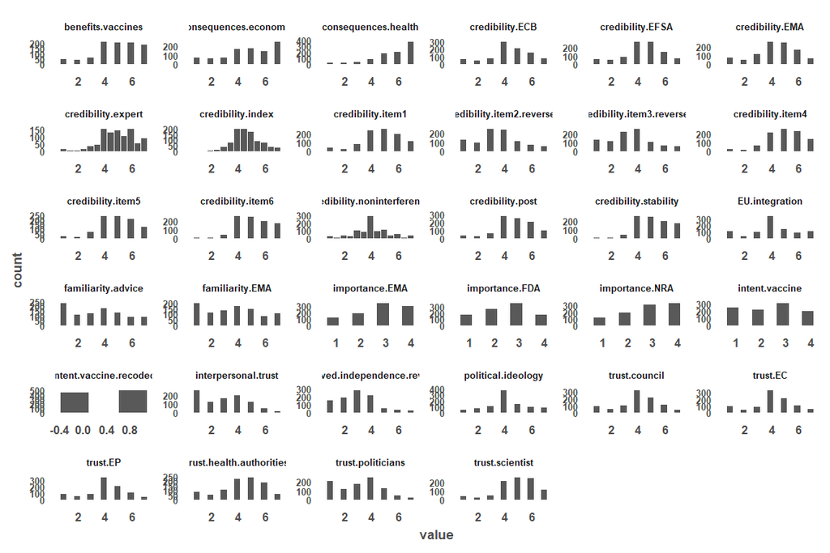

```r
df.def %>% select(benefits.vaccines, intent.vaccine:importance.NRA) %>%
  gather() %>%
  ggplot(aes(value)) +
    facet_wrap(~ key, scales = "free") +
    geom_histogram(boundary = 0.1, binwidth = 0.5) +
  theme(text = element_text(face = "bold",  size = 6), axis.text.y = element_text(size = 5))
```

# 9 Correlation matrix

```r
df.def %>%
  select(trust.EC:trust.politicians, trust.health.authorities, benefits.vaccines, credibility.index, credibility.EMA, familiarity.EMA, familiarity.advice, consequences.economic, consequences.health, age, perceived.independence.reversed, political.ideology, EU.integration, knowledge, interpersonal.trust, treatment, private.providers) %>%
  tab_corr(triangle="lower",
           remove.spaces=T,
           p.numeric = T,
           fade.ns = T,
           digits = 2,
           na.deletion="pairwise",
           title = "Correlation matrix")
```

Correlation matrix

|  | trust.EC | trust.EP | trust.council | trust.scientist | trust.politicians | trust.health.authorities | benefits.vaccines | credibility.index | credibility.EMA | familiarity.EMA | familiarity.advice | consequences.economic | consequences.health | age | perceived.independence.reversed | political.ideology | EU.integration | knowledge | interpersonal.trust | treatment | private.providers |
| --- | --- | --- | --- | --- | --- | --- | --- | --- | --- | --- | --- | --- | --- | --- | --- | --- | --- | --- | --- | --- | --- |
| trust.EC |  |  |  |  |  |  |  |  |  |  |  |  |  |  |  |  |  |  |  |  |  |
| trust.EP | 0.89 (<.001) |  |  |  |  |  |  |  |  |  |  |  |  |  |  |  |  |  |  |  |  |
| trust.council | 0.90 (<.001) | 0.92 (<.001) |  |  |  |  |  |  |  |  |  |  |  |  |  |  |  |  |  |  |  |
| trust.scientist | 0.60 (<.001) | 0.61 (<.001) | 0.60 (<.001) |  |  |  |  |  |  |  |  |  |  |  |  |  |  |  |  |  |  |
| trust.politicians | 0.58 (<.001) | 0.60 (<.001) | 0.60 (<.001) | 0.41 (<.001) |  |  |  |  |  |  |  |  |  |  |  |  |  |  |  |  |  |
| trust.health.authorities | 0.49 (<.001) | 0.51 (<.001) | 0.51 (<.001) | 0.47 (<.001) | 0.53 (<.001) |  |  |  |  |  |  |  |  |  |  |  |  |  |  |  |  |
| benefits.vaccines | 0.35 (<.001) | 0.36 (<.001) | 0.35 (<.001) | 0.47 (<.001) | 0.31 (<.001) | 0.49 (<.001) |  |  |  |  |  |  |  |  |  |  |  |  |  |  |  |
| credibility.index | 0.40 (<.001) | 0.39 (<.001) | 0.39 (<.001) | 0.45 (<.001) | 0.35 (<.001) | 0.53 (<.001) | 0.54 (<.001) |  |  |  |  |  |  |  |  |  |  |  |  |  |  |
| credibility.EMA | 0.67 (<.001) | 0.67 (<.001) | 0.66 (<.001) | 0.61 (<.001) | 0.55 (<.001) | 0.56 (<.001) | 0.51 (<.001) | 0.55 (<.001) |  |  |  |  |  |  |  |  |  |  |  |  |  |
| familiarity.EMA | 0.23 (<.001) | 0.22 (<.001) | 0.20 (<.001) | 0.22 (<.001) | 0.22 (<.001) | 0.25 (<.001) | 0.10 (<.001) | 0.18 (<.001) | 0.24 (<.001) |  |  |  |  |  |  |  |  |  |  |  |  |
| familiarity.advice | 0.22 (<.001) | 0.24 (<.001) | 0.22 (<.001) | 0.21 (<.001) | 0.23 (<.001) | 0.25 (<.001) | 0.18 (<.001) | 0.24 (<.001) | 0.26 (<.001) | 0.57 (<.001) |  |  |  |  |  |  |  |  |  |  |  |
| consequences.economic | 0.06 (.08) | 0.04 (.26) | 0.06 (.06) | 0.04 (.19) | 0.03 (.41) | -0.00 (.94) | -0.09 (<.001) | -0.14 (<.001) | 0.00 (.92) | 0.09 (.01) | -0.05 (.13) |  |  |  |  |  |  |  |  |  |  |
| consequences.health | 0.20 (<.001) | 0.17 (<.001) | 0.19 (<.001) | 0.24 (<.001) | 0.10 (<.001) | 0.24 (<.001) | 0.19 (<.001) | 0.20 (<.001) | 0.20 (<.001) | 0.10 (<.001) | 0.06 (.07) | 0.47 (<.001) |  |  |  |  |  |  |  |  |  |
| age | -0.03 (.29) | -0.03 (.29) | -0.05 (.12) | 0.06 (.04) | -0.05 (.12) | 0.11 (<.001) | 0.15 (<.001) | 0.14 (<.001) | -0.00 (.97) | 0.07 (.03) | 0.14 (<.001) | -0.21 (<.001) | 0.03 (.31) |  |  |  |  |  |  |  |  |
| perceived.independence.reversed | 0.04 (.17) | 0.01 (.74) | -0.00 (.89) | -0.02 (.44) | 0.00 (.89) | 0.05 (.10) | 0.02 (.48) | 0.18 (<.001) | 0.05 (.12) | -0.12 (<.001) | -0.08 (.01) | -0.12 (<.001) | -0.06 (.05) | 0.00 (.91) |  |  |  |  |  |  |  |
| political.ideology | -0.07 (.04) | -0.06 (.06) | -0.05 (.11) | 0.02 (.43) | 0.07 (.04) | 0.02 (.48) | 0.06 (.08) | 0.01 (.84) | -0.00 (.97) | 0.06 (.06) | 0.04 (.26) | 0.02 (.52) | -0.01 (.71) | 0.03 (.31) | -0.10 (<.001) |  |  |  |  |  |  |
| EU.integration | 0.41 (<.001) | 0.42 (<.001) | 0.42 (<.001) | 0.30 (<.001) | 0.29 (<.001) | 0.36 (<.001) | 0.31 (<.001) | 0.35 (<.001) | 0.35 (<.001) | 0.20 (<.001) | 0.29 (<.001) | 0.01 (.82) | 0.12 (<.001) | 0.07 (.03) | -0.00 (.94) | -0.05 (.12) |  |  |  |  |  |
| knowledge | -0.05 (.14) | -0.05 (.13) | -0.05 (.09) | 0.00 (.90) | -0.08 (.02) | -0.00 (.93) | 0.05 (.11) | 0.05 (.12) | -0.03 (.31) | -0.04 (.20) | 0.08 (.01) | -0.00 (.94) | 0.08 (.01) | 0.13 (<.001) | 0.06 (.05) | -0.00 (.94) | 0.04 (.26) |  |  |  |  |
| interpersonal.trust | 0.26 (<.001) | 0.28 (<.001) | 0.25 (<.001) | 0.16 (<.001) | 0.27 (<.001) | 0.26 (<.001) | 0.16 (<.001) | 0.17 (<.001) | 0.19 (<.001) | 0.21 (<.001) | 0.26 (<.001) | -0.11 (<.001) | -0.10 (<.001) | 0.04 (.18) | -0.04 (.22) | 0.02 (.46) | 0.28 (<.001) | -0.07 (.03) |  |  |  |
| treatment | -0.01 (.65) | -0.01 (.68) | -0.01 (.75) | 0.02 (.44) | 0.01 (.80) | 0.00 (.91) | 0.01 (.67) | 0.01 (.70) | 0.01 (.65) | -0.01 (.73) | -0.01 (.73) | 0.04 (.21) | 0.00 (.92) | 0.02 (.49) | 0.04 (.17) | 0.03 (.35) | 0.03 (.35) | -0.04 (.18) | 0.02 (.48) |  |  |
| private.providers | 0.02 (.56) | -0.01 (.85) | 0.02 (.53) | 0.07 (.02) | 0.08 (.01) | 0.03 (.32) | 0.03 (.36) | 0.05 (.15) | 0.04 (.22) | 0.16 (<.001) | 0.01 (.71) | 0.10 (<.001) | 0.03 (.41) | 0.01 (.77) | -0.12 (<.001) | 0.26 (<.001) | -0.01 (.66) | -0.07 (.02) | -0.02 (.57) | 0.04 (.20) |  |
| Computed correlation used pearson-method with pairwise-deletion. |  |  |  |  |  |  |  |  |  |  |  |  |  |  |  |  |  |  |  |  |  |

# 10 Regression

## 10.1 Perceived independence

```r
reg.perceived.independence1 <- lm(perceived.independence.reversed ~  trust.politicians + trust.scientist + trust.EC + trust.health.authorities + interpersonal.trust + benefits.vaccines + credibility.EMA + familiarity.EMA + familiarity.advice +  political.ideology + consequences.health + consequences.economic + EU.integration + private.providers + knowledge +  experimental.group + female + poly(age, 2) + healthcare + income,
                    data = df.def,
                    na.action = na.omit)

reg.perceived.independence2 <- lm(perceived.independence.reversed ~ trust.politicians + trust.scientist + trust.EC + trust.health.authorities + interpersonal.trust + benefits.vaccines + credibility.EMA + familiarity.EMA + familiarity.advice +  political.ideology + consequences.health + consequences.economic +  EU.integration + private.providers + knowledge +  experimental.group + female + poly(age, 2) + healthcare + income,
                    data = df.def,
                    na.action = na.omit)


tab_model(reg.perceived.independence1, reg.perceived.independence2,  show.ci = FALSE)
```

|  | perceived independence reversed |  | perceived independence reversed |  |
| --- | --- | --- | --- | --- |
| Predictors | Estimates | p | Estimates | p |
| (Intercept) | 4.22 | **<0.001** | 4.22 | **<0.001** |
| trust.politicians | -0.03 | 0.465 | -0.03 | 0.465 |
| trust.scientist | -0.09 | **0.041** | -0.09 | **0.041** |
| trust.EC | 0.08 | 0.097 | 0.08 | 0.097 |
| trust.health.authorities | 0.08 | **0.032** | 0.08 | **0.032** |
| interpersonal.trust | -0.05 | 0.117 | -0.05 | 0.117 |
| benefits.vaccines | -0.01 | 0.882 | -0.01 | 0.882 |
| credibility.EMA | 0.07 | 0.157 | 0.07 | 0.157 |
| familiarity.EMA | -0.05 | 0.085 | -0.05 | 0.085 |
| familiarity.advice | -0.04 | 0.179 | -0.04 | 0.179 |
| political.ideology | -0.07 | **0.022** | -0.07 | **0.022** |
| consequences.health | -0.05 | 0.193 | -0.05 | 0.193 |
| consequences.economic | -0.07 | **0.025** | -0.07 | **0.025** |
| EU.integration | -0.02 | 0.520 | -0.02 | 0.520 |
| private.providers | -0.08 | **0.011** | -0.08 | **0.011** |
| knowledge | 0.21 | **0.031** | 0.21 | **0.031** |
| experimental.group [treatment] | 0.16 | 0.082 | 0.16 | 0.082 |
| female | -0.01 | 0.939 | -0.01 | 0.939 |
| age [1st degree] | -0.59 | 0.708 | -0.59 | 0.708 |
| age [2nd degree] | 1.16 | 0.439 | 1.16 | 0.439 |
| healthcare [yes] | -0.19 | 0.324 | -0.19 | 0.324 |
| income20K-25K | 0.19 | 0.195 | 0.19 | 0.195 |
| income25K-30K | 0.22 | 0.207 | 0.22 | 0.207 |
| income30K-35K | 0.01 | 0.943 | 0.01 | 0.943 |
| income35K-40K | 0.10 | 0.559 | 0.10 | 0.559 |
| income40K-45K | 0.46 | **0.013** | 0.46 | **0.013** |
| income45K-50K | 0.14 | 0.525 | 0.14 | 0.525 |
| income [50K>] | 0.15 | 0.393 | 0.15 | 0.393 |
| Observations | 988 |  | 988 |  |
| R<sup>2</sup> / R<sup>2</sup> adjusted | 0.075 / 0.049 |  | 0.075 / 0.049 |  |

## 10.2 Vaccination intension

```r
reg.intent.vaccine1 <- glm(intent.vaccine.recoded ~ trust.politicians + trust.scientist + trust.EC + trust.health.authorities + interpersonal.trust + benefits.vaccines + credibility.EMA + familiarity.EMA + familiarity.advice +  political.ideology + consequences.health + consequences.economic + EU.integration + private.providers + knowledge +  experimental.group + female + age + healthcare + income,
                    data = df.def,
                    na.action = na.omit,
                    family = binomial(link = 'logit'))

reg.intent.vaccine2 <- glm(intent.vaccine.recoded ~ credibility.index + trust.politicians + trust.scientist + trust.EC + trust.health.authorities + interpersonal.trust + benefits.vaccines + credibility.EMA + familiarity.EMA + familiarity.advice +  political.ideology + consequences.health + consequences.economic + EU.integration + private.providers + knowledge +  experimental.group + female + age + healthcare + income,
                    data = df.def,
                    na.action = na.omit,
                    family = binomial(link = 'logit'))

reg.intent.vaccine3 <- glm(intent.vaccine.recoded ~ perceived.independence.reversed + trust.politicians + trust.scientist + trust.EC + trust.health.authorities + interpersonal.trust + benefits.vaccines + credibility.EMA + familiarity.EMA + familiarity.advice +  political.ideology + consequences.health + consequences.economic + EU.integration + private.providers + knowledge +  experimental.group + female + age + healthcare + income,
                    data = df.def,
                    na.action = na.omit,
                    family = binomial(link = 'logit'))

reg.intent.vaccine4 <- glm(intent.vaccine.recoded ~ credibility.index + perceived.independence.reversed + trust.politicians + trust.scientist + trust.EC + trust.health.authorities + interpersonal.trust + benefits.vaccines + credibility.EMA + familiarity.EMA + familiarity.advice +  political.ideology + consequences.health + consequences.economic + EU.integration + private.providers + knowledge +  experimental.group + female + age + healthcare + income,
                    data = df.def,
                    na.action = na.omit,
                    family = binomial(link = 'logit'))

tab_model(reg.intent.vaccine1, reg.intent.vaccine2, reg.intent.vaccine3, reg.intent.vaccine4, show.ci = FALSE)
```

|  | intent vaccine recoded |  | intent vaccine recoded |  | intent vaccine recoded |  | intent vaccine recoded |  |
| --- | --- | --- | --- | --- | --- | --- | --- | --- |
| Predictors | Odds Ratios | p | Odds Ratios | p | Odds Ratios | p | Odds Ratios | p |
| (Intercept) | 0.00 | **<0.001** | 0.00 | **<0.001** | 0.00 | **<0.001** | 0.00 | **<0.001** |
| trust.politicians | 1.02 | 0.732 | 1.02 | 0.760 | 1.02 | 0.732 | 1.02 | 0.761 |
| trust.scientist | 1.10 | 0.249 | 1.08 | 0.372 | 1.10 | 0.231 | 1.07 | 0.383 |
| trust.EC | 1.11 | 0.201 | 1.14 | 0.134 | 1.11 | 0.216 | 1.14 | 0.131 |
| trust.health.authorities | 1.44 | **<0.001** | 1.34 | **<0.001** | 1.43 | **<0.001** | 1.35 | **<0.001** |
| interpersonal.trust | 1.18 | **0.003** | 1.19 | **0.003** | 1.19 | **0.003** | 1.19 | **0.003** |
| benefits.vaccines | 1.76 | **<0.001** | 1.64 | **<0.001** | 1.76 | **<0.001** | 1.64 | **<0.001** |
| credibility.EMA | 0.92 | 0.312 | 0.82 | **0.024** | 0.92 | 0.299 | 0.82 | **0.023** |
| familiarity.EMA | 1.04 | 0.419 | 1.04 | 0.531 | 1.05 | 0.400 | 1.03 | 0.540 |
| familiarity.advice | 1.00 | 0.934 | 1.00 | 0.970 | 1.01 | 0.907 | 1.00 | 0.977 |
| political.ideology | 1.17 | **0.007** | 1.19 | **0.005** | 1.17 | **0.006** | 1.18 | **0.005** |
| consequences.health | 1.33 | **<0.001** | 1.29 | **<0.001** | 1.34 | **<0.001** | 1.29 | **<0.001** |
| consequences.economic | 0.85 | **0.004** | 0.90 | 0.076 | 0.85 | **0.005** | 0.90 | 0.075 |
| EU.integration | 1.10 | 0.109 | 1.06 | 0.316 | 1.10 | 0.104 | 1.06 | 0.320 |
| private.providers | 0.94 | 0.279 | 0.91 | 0.114 | 0.94 | 0.297 | 0.91 | 0.111 |
| knowledge | 0.90 | 0.528 | 0.86 | 0.400 | 0.89 | 0.490 | 0.87 | 0.411 |
| experimental.group [treatment] | 1.11 | 0.544 | 1.08 | 0.652 | 1.09 | 0.600 | 1.08 | 0.640 |
| female | 0.58 | **0.002** | 0.56 | **0.001** | 0.58 | **0.002** | 0.56 | **0.001** |
| age | 1.02 | **<0.001** | 1.02 | **<0.001** | 1.02 | **<0.001** | 1.02 | **<0.001** |
| healthcare [yes] | 0.91 | 0.773 | 0.93 | 0.837 | 0.91 | 0.784 | 0.93 | 0.834 |
| income20K-25K | 0.81 | 0.387 | 0.83 | 0.465 | 0.80 | 0.377 | 0.83 | 0.468 |
| income25K-30K | 1.37 | 0.300 | 1.43 | 0.251 | 1.36 | 0.316 | 1.44 | 0.248 |
| income30K-35K | 0.81 | 0.508 | 0.80 | 0.505 | 0.81 | 0.506 | 0.80 | 0.508 |
| income35K-40K | 1.14 | 0.657 | 1.12 | 0.715 | 1.13 | 0.674 | 1.12 | 0.710 |
| income40K-45K | 1.12 | 0.741 | 1.19 | 0.614 | 1.10 | 0.776 | 1.19 | 0.606 |
| income45K-50K | 1.44 | 0.350 | 1.30 | 0.508 | 1.44 | 0.352 | 1.29 | 0.508 |
| income [50K>] | 0.96 | 0.904 | 0.90 | 0.754 | 0.96 | 0.903 | 0.90 | 0.755 |
| credibility.index |  |  | 1.91 | **<0.001** |  |  | 1.91 | **<0.001** |
| perceived.independence.reversed |  |  |  |  | 1.04 | 0.529 | 0.99 | 0.852 |
| Observations | 988 |  | 988 |  | 988 |  | 988 |  |
| R<sup>2</sup> Tjur | 0.395 |  | 0.419 |  | 0.395 |  | 0.419 |  |

## 10.3 Crebility of EMA’s decision

```r
reg.credibility1 <- lm(credibility.index  ~ trust.politicians + trust.scientist + trust.EC + trust.health.authorities + interpersonal.trust + benefits.vaccines + credibility.EMA + familiarity.EMA + familiarity.advice + political.ideology + consequences.health + consequences.economic + EU.integration + private.providers + knowledge +  experimental.group + female + poly(age, 2) + healthcare + income,
                    data = df.def,
                    na.action = na.omit)

reg.credibility2 <- lm(credibility.index  ~ perceived.independence.reversed + trust.politicians + trust.scientist + trust.EC + trust.health.authorities + interpersonal.trust + benefits.vaccines + credibility.EMA + familiarity.EMA + familiarity.advice +  political.ideology + consequences.health + consequences.economic + EU.integration + private.providers + knowledge +  experimental.group + female + poly(age, 2) + healthcare + income,
                    data = df.def,
                    na.action = na.omit)

reg.credibility3 <- lm(credibility.index  ~ perceived.independence.reversed + trust.politicians + trust.scientist + trust.EC + trust.health.authorities + interpersonal.trust + benefits.vaccines + credibility.EMA + familiarity.EMA +  + familiarity.advice +  political.ideology + consequences.health + consequences.economic + EU.integration + private.providers + knowledge +  experimental.group + female + poly(age, 2) + healthcare + income + perceived.independence.reversed:benefits.vaccines + benefits.vaccines:experimental.group,
                    data = df.def,
                    na.action = na.omit)

reg.credibility4 <- lm(credibility.index  ~ perceived.independence.reversed + trust.politicians + trust.scientist + trust.EC + trust.health.authorities + interpersonal.trust + benefits.vaccines + credibility.EMA + familiarity.EMA +  + familiarity.advice +  political.ideology + consequences.health + consequences.economic + EU.integration + private.providers + knowledge +  experimental.group + female + age.recoded + healthcare + income + perceived.independence.reversed:benefits.vaccines + benefits.vaccines:experimental.group,
                    data = df.def,
                    na.action = na.omit)


reg.credibility3.centered <- meanCenter(reg.credibility3, centerOnlyInteractors = TRUE, centerDV = FALSE)

reg.credibility4.centered <- meanCenter(reg.credibility4, centerOnlyInteractors = TRUE, centerDV = FALSE)

tab_model(reg.credibility1, reg.credibility2, reg.credibility3.centered, show.ci = FALSE)
```

|  | credibility index |  | credibility index |  | credibility index |  |
| --- | --- | --- | --- | --- | --- | --- |
| Predictors | Estimates | p | Estimates | p | Estimates | p |
| (Intercept) | 1.98 | **<0.001** | 1.48 | **<0.001** | 2.58 | **<0.001** |
| trust.politicians | -0.00 | 0.823 | -0.00 | 0.944 | 0.00 | 0.954 |
| trust.scientist | 0.04 | 0.069 | 0.05 | **0.021** | 0.06 | **0.020** |
| trust.EC | -0.02 | 0.402 | -0.03 | 0.223 | -0.03 | 0.213 |
| trust.health.authorities | 0.13 | **<0.001** | 0.12 | **<0.001** | 0.12 | **<0.001** |
| interpersonal.trust | -0.00 | 0.928 | 0.00 | 0.803 | 0.00 | 0.814 |
| benefits.vaccines | 0.15 | **<0.001** | 0.15 | **<0.001** |  |  |
| credibility.EMA | 0.17 | **<0.001** | 0.16 | **<0.001** | 0.16 | **<0.001** |
| familiarity.EMA | 0.01 | 0.753 | 0.01 | 0.486 | 0.01 | 0.408 |
| familiarity.advice | 0.01 | 0.502 | 0.02 | 0.328 | 0.01 | 0.396 |
| political.ideology | -0.01 | 0.433 | -0.01 | 0.764 | -0.00 | 0.777 |
| consequences.health | 0.08 | **<0.001** | 0.08 | **<0.001** | 0.08 | **<0.001** |
| consequences.economic | -0.09 | **<0.001** | -0.09 | **<0.001** | -0.09 | **<0.001** |
| EU.integration | 0.06 | **0.001** | 0.06 | **0.001** | 0.06 | **<0.001** |
| private.providers | 0.03 | 0.123 | 0.03 | **0.033** | 0.03 | **0.034** |
| knowledge | 0.05 | 0.298 | 0.03 | 0.555 | 0.03 | 0.605 |
| experimental.group [treatment] | 0.02 | 0.711 | -0.00 | 0.999 | 0.00 | 0.941 |
| female | 0.01 | 0.906 | 0.01 | 0.891 | 0.01 | 0.828 |
| age [1st degree] | 0.68 | 0.429 | 0.75 | 0.373 | 0.57 | 0.496 |
| age [2nd degree] | -0.16 | 0.846 | -0.29 | 0.713 | -0.32 | 0.687 |
| healthcare [yes] | -0.09 | 0.384 | -0.07 | 0.500 | -0.06 | 0.564 |
| income20K-25K | -0.02 | 0.800 | -0.04 | 0.588 | -0.05 | 0.553 |
| income25K-30K | -0.04 | 0.661 | -0.07 | 0.469 | -0.07 | 0.484 |
| income30K-35K | 0.01 | 0.921 | 0.01 | 0.932 | 0.01 | 0.933 |
| income35K-40K | -0.02 | 0.841 | -0.03 | 0.740 | -0.02 | 0.784 |
| income40K-45K | 0.00 | 0.991 | -0.05 | 0.596 | -0.06 | 0.528 |
| income45K-50K | 0.06 | 0.587 | 0.05 | 0.677 | 0.05 | 0.697 |
| income [50K>] | 0.09 | 0.378 | 0.07 | 0.475 | 0.07 | 0.482 |
| perceived.independence.reversed |  |  | 0.12 | **<0.001** |  |  |
| perceived.independence.reversedc |  |  |  |  | 0.12 | **<0.001** |
| benefits.vaccinesc |  |  |  |  | 0.16 | **<0.001** |
| perceived.independence.reversedc * benefits.vaccinesc |  |  |  |  | 0.02 | **0.025** |
| benefits.vaccinesc * experimental.group [treatment] |  |  |  |  | -0.02 | 0.620 |
| Observations | 988 |  | 988 |  | 988 |  |
| R<sup>2</sup> / R<sup>2</sup> adjusted | 0.466 / 0.451 |  | 0.490 / 0.475 |  | 0.493 / 0.477 |  |

*Note: Interaction variables are centered in the third model*

### 10.3.1 Plots

*Interaction effect: perceived independence x benefits of vaccines*

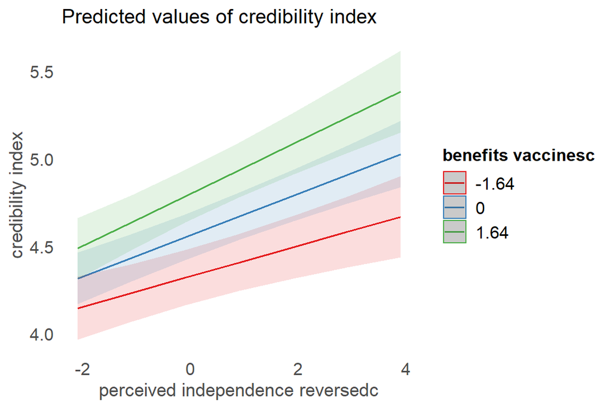

```r
plot_model(reg.credibility3.centered, type = "int", mdrt.values = "meansd")[[1]]
```

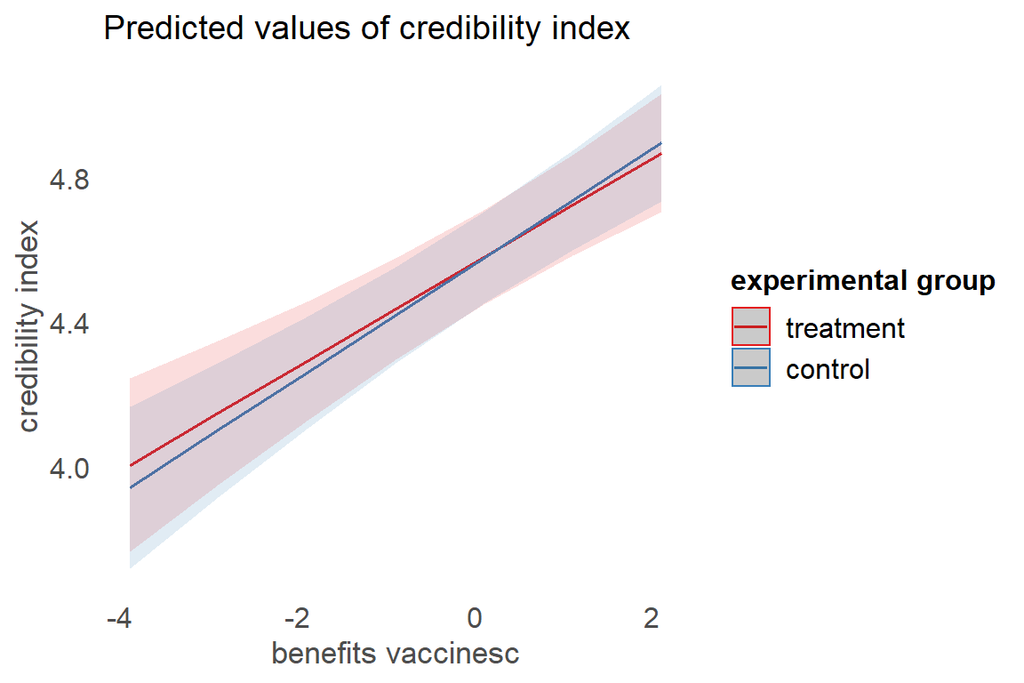

```r
plot_model(reg.credibility3.centered, type = "int", mdrt.values = "meansd")[[2]]
```

*marginal effects: Effect of perceived independence on credibility for different age groups*

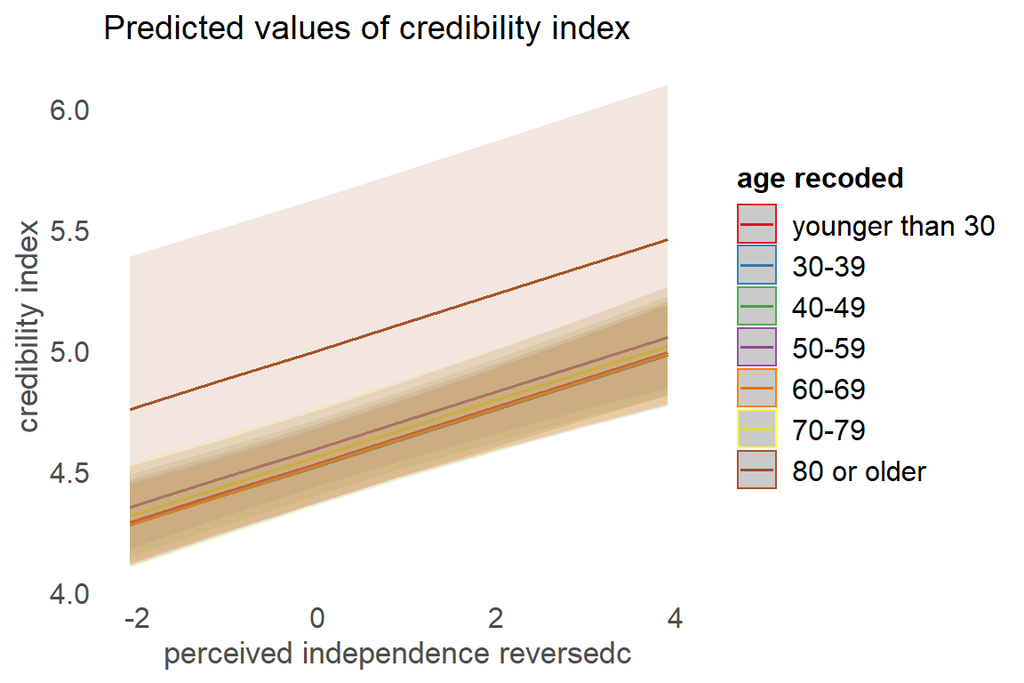

```r
plot_model(reg.credibility4.centered, type = "pred", terms = c("perceived.independence.reversedc", "age.recoded"))
```

## 10.4 Full models - filtered

### 10.4.1 Perceived independence

```r
reg.perceived.independence.30 <- lm(perceived.independence.reversed ~ trust.politicians + trust.scientist + trust.EC + trust.health.authorities + interpersonal.trust + benefits.vaccines + credibility.EMA + familiarity.EMA + familiarity.advice +  political.ideology + consequences.health + consequences.economic +  EU.integration + private.providers + knowledge +  experimental.group + female + poly(age, 2) + healthcare + income,
                    data = df.30,
                    na.action = na.omit)

reg.perceived.independence.check <- lm(perceived.independence.reversed ~  trust.politicians + trust.scientist + trust.EC + trust.health.authorities + interpersonal.trust + benefits.vaccines + credibility.EMA + familiarity.EMA + familiarity.advice +  political.ideology + consequences.health + consequences.economic +  EU.integration + private.providers + knowledge +  experimental.group + female + poly(age, 2) + healthcare + income,
                    data = df.check,
                    na.action = na.omit)

tab_model(reg.perceived.independence.30, reg.perceived.independence.check, dv.labels = c("Perceived independence (filter = page submission)", "Perceived independence (filter = manipulation check)"), show.ci = FALSE)
```

|  | Perceived independence (filter = page submission) |  | Perceived independence (filter = manipulation check) |  |
| --- | --- | --- | --- | --- |
| Predictors | Estimates | p | Estimates | p |
| (Intercept) | 3.52 | **<0.001** | 3.09 | **<0.001** |
| trust.politicians | -0.01 | 0.855 | 0.04 | 0.434 |
| trust.scientist | -0.01 | 0.950 | -0.07 | 0.260 |
| trust.EC | 0.00 | 0.972 | 0.09 | 0.158 |
| trust.health.authorities | 0.09 | 0.233 | 0.10 | 0.061 |
| interpersonal.trust | 0.04 | 0.555 | -0.06 | 0.153 |
| benefits.vaccines | -0.04 | 0.560 | -0.02 | 0.694 |
| credibility.EMA | 0.20 | **0.040** | 0.06 | 0.357 |
| familiarity.EMA | -0.14 | **0.013** | -0.06 | 0.107 |
| familiarity.advice | 0.02 | 0.757 | -0.02 | 0.598 |
| political.ideology | -0.05 | 0.468 | -0.07 | 0.114 |
| consequences.health | -0.11 | 0.122 | 0.02 | 0.762 |
| consequences.economic | -0.04 | 0.437 | -0.06 | 0.116 |
| EU.integration | -0.01 | 0.822 | 0.01 | 0.718 |
| private.providers | -0.03 | 0.651 | -0.04 | 0.295 |
| knowledge | 0.22 | 0.237 | 0.28 | **0.031** |
| experimental.group [treatment] | 0.23 | 0.205 | 0.35 | **0.007** |
| female | -0.06 | 0.754 | 0.01 | 0.922 |
| age [1st degree] | -1.06 | 0.521 | -0.72 | 0.654 |
| age [2nd degree] | -0.39 | 0.805 | 0.35 | 0.813 |
| healthcare [yes] | 0.06 | 0.891 | -0.36 | 0.205 |
| income20K-25K | 0.05 | 0.850 | 0.12 | 0.530 |
| income25K-30K | -0.26 | 0.417 | 0.21 | 0.357 |
| income30K-35K | -0.21 | 0.502 | -0.00 | 0.992 |
| income35K-40K | -0.21 | 0.517 | 0.00 | 0.992 |
| income40K-45K | 0.51 | 0.134 | 0.35 | 0.179 |
| income45K-50K | 1.02 | **0.040** | 0.34 | 0.269 |
| income [50K>] | 0.21 | 0.557 | 0.17 | 0.463 |
| Observations | 296 |  | 551 |  |
| R<sup>2</sup> / R<sup>2</sup> adjusted | 0.136 / 0.050 |  | 0.095 / 0.048 |  |

### 10.4.2 Vaccination intention

Too few cases.

### 10.4.3 Credibility index

```r
reg.credibility.30 <- lm(credibility.index  ~ perceived.independence.reversed + trust.politicians + trust.scientist + trust.EC + trust.health.authorities + interpersonal.trust + benefits.vaccines + credibility.EMA + familiarity.EMA +  + familiarity.advice +  political.ideology + consequences.health + consequences.economic + EU.integration + private.providers + knowledge +  experimental.group + female + poly(age, 2) + healthcare + income + perceived.independence.reversed:benefits.vaccines + benefits.vaccines:experimental.group,
                    data = df.30,
                    na.action = na.omit)

reg.credibility.check <- lm(credibility.index  ~ perceived.independence.reversed + trust.politicians + trust.scientist + trust.EC + trust.health.authorities + interpersonal.trust + benefits.vaccines + credibility.EMA + familiarity.EMA +  + familiarity.advice +  political.ideology + consequences.health + consequences.economic + EU.integration + private.providers + knowledge +  experimental.group + female + poly(age, 2) + healthcare + income + perceived.independence.reversed:benefits.vaccines + benefits.vaccines:experimental.group,
                    data = df.check,
                    na.action = na.omit)

tab_model(reg.credibility.30, reg.credibility.check, dv.labels = c("Credibility (filter = page submission)",  "Credibility (filter = manipulation check)"), show.ci = FALSE)
```

|  | Credibility (filter = page submission) |  | Credibility (filter = manipulation check) |  |
| --- | --- | --- | --- | --- |
| Predictors | Estimates | p | Estimates | p |
| (Intercept) | 2.22 | **<0.001** | 1.76 | **<0.001** |
| perceived.independence.reversed | -0.02 | 0.850 | -0.06 | 0.363 |
| trust.politicians | -0.00 | 0.930 | -0.01 | 0.843 |
| trust.scientist | 0.10 | **0.025** | 0.07 | **0.031** |
| trust.EC | -0.06 | 0.196 | -0.03 | 0.412 |
| trust.health.authorities | 0.15 | **<0.001** | 0.10 | **0.001** |
| interpersonal.trust | -0.06 | 0.078 | 0.01 | 0.574 |
| benefits.vaccines | 0.13 | 0.075 | 0.06 | 0.178 |
| credibility.EMA | 0.09 | 0.074 | 0.14 | **<0.001** |
| familiarity.EMA | -0.01 | 0.800 | 0.00 | 0.885 |
| familiarity.advice | 0.01 | 0.644 | 0.03 | 0.237 |
| political.ideology | 0.05 | 0.148 | -0.00 | 0.981 |
| consequences.health | -0.03 | 0.384 | 0.11 | **<0.001** |
| consequences.economic | -0.05 | 0.103 | -0.09 | **<0.001** |
| EU.integration | 0.06 | 0.070 | 0.06 | **0.007** |
| private.providers | -0.02 | 0.465 | 0.04 | 0.064 |
| knowledge | -0.07 | 0.439 | -0.02 | 0.753 |
| experimental.group [treatment] | 0.60 | 0.067 | 0.09 | 0.675 |
| female | -0.07 | 0.504 | 0.08 | 0.269 |
| age [1st degree] | 0.69 | 0.420 | 0.11 | 0.894 |
| age [2nd degree] | 1.03 | 0.207 | -0.96 | 0.225 |
| healthcare [yes] | 0.02 | 0.943 | -0.01 | 0.966 |
| income20K-25K | 0.11 | 0.452 | -0.05 | 0.623 |
| income25K-30K | 0.07 | 0.664 | -0.11 | 0.377 |
| income30K-35K | 0.20 | 0.219 | -0.09 | 0.473 |
| income35K-40K | 0.22 | 0.181 | 0.01 | 0.902 |
| income40K-45K | 0.04 | 0.815 | 0.02 | 0.879 |
| income45K-50K | 0.63 | **0.014** | 0.22 | 0.184 |
| income [50K>] | 0.03 | 0.881 | 0.11 | 0.404 |
| perceived.independence.reversed * benefits.vaccines | 0.04 | **0.042** | 0.04 | **0.004** |
| benefits.vaccines * experimental.group [treatment] | -0.10 | 0.106 | 0.01 | 0.800 |
| Observations | 296 |  | 551 |  |
| R<sup>2</sup> / R<sup>2</sup> adjusted | 0.545 / 0.494 |  | 0.527 / 0.500 |  |

# 11 Familiarity

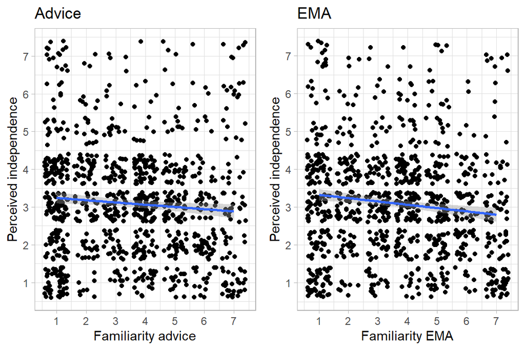

```r
p15 <-  df.def %>% ggplot(aes(familiarity.advice, perceived.independence.reversed)) + geom_jitter() + geom_smooth(method = "lm") + scale_x_continuous("Familiarity advice", breaks = 1:7) + scale_y_continuous("Perceived independence", breaks = 1:7) + labs(title = "Advice") + theme_light()

p16 <-  df.def %>% ggplot(aes(familiarity.EMA, perceived.independence.reversed)) + geom_jitter() + geom_smooth(method = "lm") + scale_x_continuous("Familiarity EMA", breaks = 1:7) + scale_y_continuous("Perceived independence", breaks = 1:7) + labs(title = "EMA") + theme_light()

ggarrange(p15, p16,
          ncol = 2,nrow = 1)
```

# 12 Remarks from participants

```r
df.total %>%
  filter(nchar(comments.general)>1) %>%
  select(comments.general) %>%
  kable() %>%
  kable_styling(bootstrap_options = "striped", full_width = F) %>%    scroll_box(height = "400px")
```

[output not shown]